# Field Experiment

- Show All Code
- Hide All Code
- View Source

Replication Report

Author

Affiliation

*blinded for review*

*blinded for review*

# 1 Introduction

In our main study, we ran a field experiment in which we varied the visual fluency and the substantive quality of pitch decks of our two fictitious startups (Software: **PerkSouq**; Healthcare: **Brachytix**).

Specifically, we sent out a standardized email to 39,977 potential investors (24,961 for the software startup and 15,016 for healthcare startup), and tracked whether the potential investor clicks on the link to the pitch deck. Every investor who clicked the link within 21 days of receiving the email was potentially part of our sample (pending exclusion restrictions). All data that was recorded within 21 days after an investor clicked on the link to the pitch deck was considered for analysis.

Depending on their previous investment record, investors were matched to either the software startup or healthcare startup, then randomly assigned to one of the four experimental conditions. We pretested all the manipulations. We tracked whether an investor clicked on the link to the pitch deck, the cumulative time the pitch deck remained open, the percentage of slides viewed, and whether there was a positive reaction to the email. A reaction was considered positive if a meeting appointment was scheduled over a link in the deck and / or an email reply has been sent that clearly demonstrated investor interest.[^1] Participants were not aware that they took part in a scientific study and that the startups were fictitious.

For more details, e.g., on the exclusion criteria that we used, see the corresponding [AsPredicted](https://aspredicted.org) pre-registration listed in Table 1.

Table 1: Overview Pre-Registration

| Startup | Pre-Reg Date | AsPredicted # | Data Collection Start |
| --- | --- | --- | --- |
| PerkSouq & Brachytix | 13-01-2023 | [118675](https://aspredicted.org/CSW_2W8) | 16-01-2023 |

In what follows, we will give an overview of the results, separately for each startup, followed by figures that summarize the results of the field experiment. As this report is dynamically created with R and Quarto, we also report all code. However, for readability, code is hidden by default and only the relevant results are shown. You can expand individual code blocks by clicking on them, or use the `</> Code` button (top-right) to reveal all code or view the complete source.

```r
# setup
library(here)
library(dplyr)
library(knitr)
library(ggplot2)
library(ggtext)
library(ggsankey)
library(ggsignif)
library(patchwork)
library(kableExtra)
options(knitr.kable.NA = '',
        kable_styling_bootstrap_options = c("striped", "condensed", "responsive"))

# further packages that are loaded on demand are:
# - supernova
# - weights
# - parameters
# - broom
# - scales
# - performance
# - readr
# - lubridate
# - stringr
# - tidyr
# - irr
# - AER
# - hrbrthemes
# - grid
# - gridExtra



# Custom functions
#
# negate %in%
`%notin%` <- Negate(`%in%`)
#
# extract ANOVA results including eta squared and put the results together as a table
# -Note: needs the supernova library installed
anova_tbl <- function(formula, data, type = 3, ...){
  # perform ANOVA
  d <- supernova::supernova(lm(as.formula(deparse(formula)), data = data), type = type)$tbl
  # check whether ANOVA is univariate or factorial
  univariate <- all(d$term %in% c("Model", "Error", "Total"))
  # get rows of interest
  if(univariate) {
    effect_rows <- d$term %notin% c("Error", "Total")
  } else {
    effect_rows <- d$term %notin% c("Model", "Error", "Total")
  }
  # extract key parameters
  effect <- d$term[effect_rows]
  MSE <- round(d$MS[effect_rows], 2)
  df <- d$df[effect_rows]
  df_res <- d$df[d$term == "Error"]
  statistic <- round(d$F[effect_rows], 2)
  pval <- ifelse(d$p[effect_rows] < .001, " &lt; .001", weights::rd(d$p[effect_rows], 3))
  eta <- ifelse(d$PRE[effect_rows] < .001, " &lt; .001", weights::rd(d$PRE[effect_rows], 3))
  # construct return df
  return(data.frame(effect, MSE, df, df_res, statistic, pval, eta))
}
# extract GLM results and put the results together as a table
glm_tbl <- function(model, coef_digits = 2, coef_bold = TRUE, p_threshold = 0.05, ...){
  # extract model parameters
  if("tobit" %in% class(model)){ # tobit model -> broom::tidy does not work
    res <- parameters::model_parameters(model)
    res <- res[c("Parameter", "Coefficient", "SE", "z", "p")]
    names(res) <- c("term", "estimate", "std.error", "statistic", "p.value")
    # res[] <- lapply(res, function(x) { attributes(x) <- NULL; x })
  } else {
    res <- broom::tidy(model)
  }
  pvals <- res$p.value
  res$estimate <- sprintf(paste0("%.", coef_digits, "f"), res$estimate)
  res$std.error <- sprintf("%.3f", res$std.error)
  res$statistic <- sprintf("%.2f", res$statistic)
  # format p value
  res$p.value <- ifelse(res$p.value < .001, " &lt; .001", weights::rd(res$p.value, 3))
  # make estimates bold if below critical p value
  if(coef_bold){
    res$estimate[pvals < p_threshold] <- paste0("<b>", res$estimate[pvals < p_threshold], "</b>")
    res$std.error[pvals < p_threshold] <- paste0("<b>", res$std.error[pvals < p_threshold], "</b>")
    res$statistic[pvals < p_threshold] <- paste0("<b>", res$statistic[pvals < p_threshold], "</b>")
    res$p.value[pvals < p_threshold] <- paste0("<b>", res$p.value[pvals < p_threshold], "</b>")
  }
  # bind R2 and Adj. R2 to model parameters
  r2 <- performance::r2(model) # extract R2
  end <- nrow(res) + seq_len(length(r2))
  res[end,"term"] <- names(r2)
  res[end,"estimate"] <- weights::rd(unlist(r2), digits = 3)
  # return result
  return(res)
}
```

# 2 Data preparation

For each experiment, the data preparation steps included loading, cleaning, and merging the pitch deck tracking data (from DocSend), the meeting appointment / email replies data, the information about when we send whom the email, and the information about the investors themselves (which we collected prior to our emails).

After merging, the pre-registered exclusions were performed, and the final, cleaned datasets were saved.

```r
data_dir <- 'replication_reports/data'

# set option to disable showing the column types when loading data with `readr`
options("readr.show_col_types" = FALSE)

# -----------------------------------------------------------------------------
# Software startup
# -----------------------------------------------------------------------------
#
# Getting and preparing the datasets
#
# Email data
emails <- readr::read_csv(here(data_dir, 'Study_1-1_Software_Emails.csv'))
# convert date (format is dd month yyyy) using lubridate::as_date()
emails$date_sent <- lubridate::as_date(emails$date_sent, format = "%d%b%Y")
emails$date_cutoff_click <- lubridate::as_date(emails$date_cutoff_click, format = "%d%b%Y")
emails$date_cutoff_activity <- lubridate::as_date(emails$date_cutoff_activity, format = "%d%b%Y")

# Message IDs
message_ids <- readr::read_csv(here(data_dir, 'Study_1-1_Software_Message_IDs.csv'))

# Participant data
participants <- readr::read_csv(here(data_dir, 'Study_1-1_Software_Participants.csv'))
# extract fluency and quality condition info using stringr::str_split
# --Note: the coding in the treatment variable was as follows:
#         fluency condition/quality condition
participants$fluency <- stringr::str_split(participants$treatment, "/", simplify = TRUE)[,1]
participants$quality <- stringr::str_split(participants$treatment, "/", simplify = TRUE)[,2]

# Replies
replies <- readr::read_csv(here(data_dir, 'Study_1-1_Software_Replies.csv'))
# convert date (format is dd month yyyy)
replies$date_reply <- lubridate::as_date(replies$date_reply, format = "%d%b%Y")

# Replies (coded)
replies_coded <- readr::read_csv(here(data_dir, 'Study_1-1_Software_Replies_coded.csv'))
# NOTE:
# - final coding is stored in variable "final_vote" (0 = not positive, 1 = positive)
# - final category is stored in variable "final_category_standardized"
#
# here, we rename the variables for coding ease and consistency
replies_coded |>
  rename(positive = final_vote, category = final_category_standardized) -> replies_coded

# Visits
visits <- readr::read_csv(here(data_dir, 'Study_1-1_Software_Visits.csv'))
# convert date (format is dd month yyyy)
visits$date_visit <- lubridate::as_date(visits$date_visit, format = "%d%b%Y")
# since we might have multiple visits per ID (i.e., per mail recipient),
# we need to create a variable that indicates the first visit
# because we have exclusion criteria based on this variable.
# note that we filter for atypical visits (as pre-registered).
#
# create variable "date_first_click" for each uuid
visits |> filter(atypical != 1) |> group_by(uuid) |> summarize(date_first_click = min(date_visit)) |> ungroup() -> temp
visits <- left_join(visits, temp, by = "uuid"); rm(temp)
# if there is no uuid (e.g., because of atypical visit), then the variable should be NA
visits$date_first_click[is.na(visits$uuid)] <- NA


# Exclusions (Part 1)
#
# pre-registered exclusions for the individual viewing sessions
#
# remove atypical visits
visits |> filter(atypical != 1) -> visits
# remove any participant where the uuid is not part of our sample or no uuid recorded (i.e, NA)
visits |> tidyr::drop_na(uuid) -> visits
visits <- visits[visits$uuid %in% emails$uuid, ]
# keep only observations for which first click occurred within 21 days of receiving the email
# (here, we need to merge the date info from the emails first)
visits |> left_join(emails |> select(uuid, date_sent), by = "uuid") -> visits
visits |> filter(date_first_click < (date_sent + 21)) -> visits
# keep only data within 21 days after participant has clicked
visits |> filter(date_visit < (date_first_click + 21)) -> visits
# now we can aggregate the individual viewing sessions per participant
#
# aggregate DVs per uuid: sum for duration, max for completion
visits |>
  group_by(uuid) |>
  summarize(
    duration = sum(duration),
    completion = max(completion),
    date_sent = unique(date_sent),
    date_first_click = unique(date_first_click)) |>
  ungroup() -> visits_agg


# Merging the data
#
# we start with the aggregated visits data and subsequently merge the other datasets
# --Note: the variable "uuid" is the unique identifier for each observation
#
# merge aggregated visits data with participant data
# --Note: only relevant columns are selected in the merge
visits_agg |> left_join(
  participants |> select(uuid, type, gender, investments, location, region, fluency, quality),
  by = "uuid") -> d
# merge coded replies into replies
#
# first add uuid to coded replies (from message_ids)
replies_coded <- left_join(replies_coded, message_ids, by = "message_id")
# now merge info to replies
replies_coded |>
  select(positive, category, uuid) |>
  right_join(replies, by = "uuid") -> replies
# merge replies into main data
d <- left_join(d, replies, by = "uuid")
# NOTE: replies data only contained data from participants who replied.
#       thus, after merging, we have NAs for those who did not reply.
#       we need to set these to 0.
#
# set default for reply as 0 instead of NA
d <- tidyr::replace_na(d, list(reply = 0)) # no reply = 0
# now, we differentiate between positive replies relative to all who replied
# and positive replies relative to all who clicked the link.
#
# so far, the variable positive contains 1 if the reply was positive and 0 otherwise,
# and NA if there was no reply. we keep this information and call this
# variable "positive_given_reply".
#
# for the second variable, we set all NAs to 0, resulting in a variable that
# describes positive replies relative to all who clicked the link. we call this
# variable just "positive". this variable thus is 1 if the reply was positive
# and 0 in all other cases (i.e., also for no reply).
d |> mutate(positive_given_reply = positive) -> d # reply rate relative to subset of those who replied
d <- tidyr::replace_na(d, list(positive = 0))            # reply rate relative to all who clicked link


# Exclusions (Part 2)
#
# pitch deck opened for less than 3 seconds or more than 30 minutes
# --Note: `duration` was measured in seconds
#         thus 30 minutes = 1800 seconds
d |> filter(!(duration < 3 | duration > 1800)) -> d
# keep only participants with reply within 21 days after first click
d |> filter(is.na(date_reply) | date_reply < (date_first_click + 21)) -> d
```

```r
# save processed data
d_sw <- d
# we also need the original visits and mails data for some descriptive statistics
visits_sw <- visits
emails_sw <- emails
replies_coded_sw <- replies_coded


# Sankey plot data
#
# we need to create a separate dataset for the sankey plot since we need to
# aggregate the data at a different level (that is, at the investor level)

# first, we need to merge visits and replies and set the exclusion criteria
visits_agg |>
  select(uuid, date_first_click, duration) |>
  left_join(replies |> select(uuid, date_reply, positive, category), by = "uuid") |>
  # exclusions
  # (1) keep only participants with reply within 21 days after first click
  filter(is.na(date_reply) | date_reply < (date_first_click + 21)) |>
  # (2) pitch deck opened for less than 3 seconds or more than 30 minutes
  filter(!(duration < 3 | duration > 1800)) -> sankey_temp

# now we aggregate the data at the investor level
participants |>
  select(uuid, `Investor type`=type) |>
  # merge hard bounce info
  left_join(emails |> select(uuid, hard_bounce), by = "uuid") |>
  # merge email opened, reply and category info (from temp data from before)
  # then save the data (and remove the temp data)
  left_join(sankey_temp |> select(uuid, date_first_click, date_reply, positive, category),
            by = "uuid") -> sankey_soft



# -----------------------------------------------------------------------------
# Healthcare startup
# -----------------------------------------------------------------------------
#
# Getting and preparing the datasets
#
# Email data
emails <- readr::read_csv(here(data_dir, 'Study_1-2_Healthcare_Emails.csv'))
# convert date (format is dd month yyyy) using lubridate::lubridate::as_date()
emails$date_sent <- lubridate::as_date(emails$date_sent, format = "%d%b%Y")
emails$date_cutoff_click <- lubridate::as_date(emails$date_cutoff_click, format = "%d%b%Y")
emails$date_cutoff_activity <- lubridate::as_date(emails$date_cutoff_activity, format = "%d%b%Y")

# Message IDs
message_ids <- readr::read_csv(here(data_dir, 'Study_1-2_Healthcare_Message_IDs.csv'))

# Participant data
participants <- readr::read_csv(here(data_dir, 'Study_1-2_Healthcare_Participants.csv'))
# extract fluency and quality condition info using stringr::str_split
# --Note: the coding in the treatment variable was as follows:
#         fluency condition/quality condition
participants$fluency <- stringr::str_split(participants$treatment, "/", simplify = TRUE)[,1]
participants$quality <- stringr::str_split(participants$treatment, "/", simplify = TRUE)[,2]

# Replies
replies <- readr::read_csv(here(data_dir, 'Study_1-2_Healthcare_Replies.csv'))
# convert date (format is dd month yyyy)
replies$date_reply <- lubridate::as_date(replies$date_reply, format = "%d%b%Y")

# Replies (coded)
replies_coded <- readr::read_csv(here(data_dir, 'Study_1-2_Healthcare_Replies_coded.csv'))
# NOTE:
# - final coding is stored in variable "final_vote" (0 = not positive, 1 = positive)
# - final category is stored in variable "final_category_standardized"
#
# here, we rename the variables for coding ease and consistency
replies_coded |>
  rename(positive = final_vote, category = final_category_standardized) -> replies_coded

# Visits
visits <- readr::read_csv(here(data_dir, 'Study_1-2_Healthcare_Visits.csv'))
# convert date (format is dd month yyyy)
visits$date_visit <- lubridate::as_date(visits$date_visit, format = "%d%b%Y")
# since we might have multiple visits per ID (i.e., per mail recipient),
# we need to create a variable that indicates the first visit
# because we have exclusion criteria based on this variable
# note that we filter for atypical visits (as pre-registered).
#
# create variable "date_first_click" for each uuid
visits |> filter(atypical != 1) |> group_by(uuid) |> summarize(date_first_click = min(date_visit)) |> ungroup() -> temp
visits <- left_join(visits, temp, by = "uuid"); rm(temp)
# if there is no uuid (e.g., because of atypical visit), then the variable should be NA
visits$date_first_click[is.na(visits$uuid)] <- NA


# Exclusions (Part 1)
#
# pre-registered exclusions for the individual viewing sessions
#
# remove atypical visits
visits |> filter(atypical != 1) -> visits
# remove any participant where the uuid is not part of our sample or no uuid recorded (i.e, NA)
visits |> tidyr::drop_na(uuid) -> visits
visits <- visits[visits$uuid %in% emails$uuid, ]
# keep only observations for which first click occurred within 21 days of receiving the email
# (here, we need to merge the date info from the emails first)
visits |> left_join(emails |> select(uuid, date_sent), by = "uuid") -> visits
visits |> filter(date_first_click < (date_sent + 21)) -> visits
# keep only data within 21 days after participant has clicked
visits |> filter(date_visit < (date_first_click + 21)) -> visits
# now we can aggregate the individual viewing sessions per participant
#
# aggregate DVs per uuid: sum for duration, max for completion
visits |>
  group_by(uuid) |>
  summarize(
    duration = sum(duration),
    completion = max(completion),
    date_sent = unique(date_sent),
    date_first_click = unique(date_first_click)) |>
  ungroup() -> visits_agg


# Merging the data
#
# we start with the aggregated visits data and subsequently merge the other datasets
# --Note: the variable "uuid" is the unique identifier for each observation

# merge aggregated visits data with participant data
# --Note: only relevant columns are selected in the merge
visits_agg |> left_join(
  participants |> select(uuid, type, gender, investments, location, region, fluency, quality),
  by = "uuid") -> d
# merge coded replies into replies
#
# first add uuid to coded replies (from message_ids)
replies_coded <- left_join(replies_coded, message_ids, by = "message_id")
# now merge info to replies
replies_coded |>
  select(positive, category, uuid) |>
  right_join(replies, by = "uuid") -> replies
# merge replies into main data
d <- left_join(d, replies, by = "uuid")

# NOTE: replies data only contained data from participants who replied.
#       thus, after merging, we have NAs for those who did not reply.
#       we need to set these to 0.
#
# set default for reply as 0 instead of NA
d <- tidyr::replace_na(d, list(reply = 0)) # no reply = 0
# now, we differentiate between positive replies relative to all who replied
# and positive replies relative to all who clicked the link.
#
# so far, the variable positive contains 1 if the reply was positive and 0 otherwise,
# and NA if there was no reply. we keep this information and call this
# variable "positive_given_reply".
#
# for the second variable, we set all NAs to 0, resulting in a variable that
# describes positive replies relative to all who clicked the link. we call this
# variable just "positive". this variable thus is 1 if the reply was positive
# and 0 in all other cases (i.e., also for no reply).
d |> mutate(positive_given_reply = positive) -> d # reply rate relative to subset of those who replied
d <- tidyr::replace_na(d, list(positive = 0))            # reply rate relative to all who clicked link
```

```r
# Exclusions (Part 2)
#
# pitch deck opened for less than 3 seconds or more than 30 minutes
# --Note: `duration` was measured in seconds
#         thus 30 minutes = 1800 seconds
d |> filter(!(duration < 3 | duration > 1800)) -> d
# keep only participants with reply within 21 days after first click
d |> filter(is.na(date_reply) | date_reply < (date_first_click + 21)) -> d

# save processed data
d_hc <- d
# we also need the original visits and mails data for some descriptive statistics
visits_hc <- visits
emails_hc <- emails
replies_coded_hc <- replies_coded


# Sankey plot data
#
# we need to create a separate dataset for the sankey plot since we need to
# aggregate the data at a different level (that is, at the investor level)

# first, we need to merge visits and replies and set the exclusion criteria
visits_agg |>
  select(uuid, date_first_click, duration) |>
  left_join(replies |> select(uuid, date_reply, positive, category), by = "uuid") |>
  # exclusions
  # (1) keep only participants with reply within 21 days after first click
  filter(is.na(date_reply) | date_reply < (date_first_click + 21)) |>
  # (2) pitch deck opened for less than 3 seconds or more than 30 minutes
  filter(!(duration < 3 | duration > 1800)) -> sankey_temp

# now we aggregate the data at the investor level
participants |>
  select(uuid, `Investor type`=type) |>
  # merge hard bounce info
  left_join(emails |> select(uuid, hard_bounce), by = "uuid") |>
  # merge email opened, reply and category info (from temp data from before)
  # then save the data (and remove the temp data)
  left_join(sankey_temp |> select(uuid, date_first_click, date_reply, positive, category),
            by = "uuid") -> sankey_health


# remove temporary objects
rm(d, emails, message_ids, participants, replies, replies_coded, visits,
   visits_agg, sankey_temp)
```

# 3 Descriptives

Table 2 gives an overview of the sample. Further descriptives and analyses are reported separately for each startup and each experiment in the following sections. In addition, Figure 1 (a) and Figure 1 (b) in Section 6 depict each sample’s flow as a Sankey diagram.

Note that the final click rates (21.0% software startup; 18.1% healthcare startup) are after having applied the pre-registered exclusion restrictions. The initial click rates were 23.1% for the software startup and 18.6% for the healthcare startup. Also note that the final number of emails sent (21,152 software; 13,335 healthcare) is smaller than originally intended (cf. Section 1) due to hard bounces (e.g., email address no longer valid).

Moreover, Table 3 shows that even after having applied the pre-registered exclusion restrictions, the click rates and final cell sizes per conditions are fairly equal.

```r
# how many mails were successfully sent (i.e., remove hard bounces)
emails_sw |> filter(hard_bounce != 1) |> summarize(N=n()) |> pull() -> n_mails_sw
emails_hc |> filter(hard_bounce != 1) |> summarize(N=n()) |> pull() -> n_mails_hc

# combine data
sample_overview <- bind_rows(list(
  Software = d_sw |> select(Fluency = fluency, Quality = quality, gender, investments, type, location, reply, positive) |> mutate(n_mails = n_mails_sw),
  Healthcare = d_hc |> select(Fluency = fluency, Quality = quality, gender, investments, type, location, reply, positive) |> mutate(n_mails = n_mails_hc)),
  .id = "Startup")
# convert Startup to factor, change order of levels
sample_overview$Startup <- factor(sample_overview$Startup, levels = c("Software", "Healthcare"))

# create table
sample_overview |>
  group_by(Startup) |>
  summarize(
    `Emails ` = scales::comma(mean(n_mails)),
    `% Click Rate` = sprintf('%.1f', mean(n() / n_mails)*100),
    `Final N` = scales::comma(n()),
    `Replies ` = scales::comma(sum(reply)),
    `Pos. Replies ` = scales::comma(sum(positive)),
    `% Female`= round(prop.table(table(gender))["female"]*100, 1),
    `Avg. Investments` = paste0(weights::rd(mean(investments, na.rm = T), 2), " (±", weights::rd(sd(investments, na.rm = T), 2), ")"),
    `% Angel Investor` = round(prop.table(table(type))["Angel"]*100, 1),
    `% US` = round(prop.table(table(location))["United States"]*100, 1)
  ) |> kbl() |> kable_styling()
```

Table 2: Sample overview for the two field experiments

| Startup | Emails | % Click Rate | Final N | Replies | Pos. Replies | % Female | Avg. Investments | % Angel Investor | % US |
| --- | --- | --- | --- | --- | --- | --- | --- | --- | --- |
| Software | 21,152 | 21.0 | 4,443 | 944 | 346 | 9.5 | 1.84 (±3.80) | 80.0 | 79.8 |
| Healthcare | 13,335 | 18.1 | 2,407 | 757 | 240 | 11.4 | 1.95 (±1.94) | 59.2 | 77.0 |

```r
# extract number of emails sent per condition
#
# first combine raw email data (excluding hard bounces)
emails <- bind_rows(list(
  Software = emails_sw,
  Healthcare = emails_hc),
  .id = "Startup") |> filter(hard_bounce != 1)
# next, extract fluency and quality condition info using stringr::str_split
# --Note: the coding in the treatment variable was as follows:
#         fluency condition/quality condition
emails$Fluency <- stringr::str_split(emails$treatment, "/", simplify = TRUE)[,1]
emails$Quality <- stringr::str_split(emails$treatment, "/", simplify = TRUE)[,2]
# convert Startup to factor, change order of levels
emails$Startup <- factor(emails$Startup, levels = c("Software", "Healthcare"))
# get the number of emails sent per condition, and add this info to the sample_overview
emails |> group_by(Startup, Fluency, Quality) |> summarize(n_mails = n()) |>
  ungroup() |>  right_join(sample_overview |> select(-n_mails), by = c("Startup", "Fluency", "Quality")) -> sample_overview

sample_overview |> group_by(Startup, Fluency, Quality) |>
  summarize(
    `Emails ` = scales::comma(mean(n_mails)),
    `% Click Rate` = sprintf('%.2f', mean(n() / n_mails)*100),
    `Final N per Condition` = scales::comma(n())
  ) |> kbl() |> kable_styling() |> row_spec(c(4), extra_css = "border-bottom: 1px solid")
```

Table 3: Randomization check

| Startup | Fluency | Quality | Emails | % Click Rate | Final N per Condition |
| --- | --- | --- | --- | --- | --- |
| Software | high | high | 5,301 | 20.58 | 1,091 |
| Software | high | low | 5,271 | 20.49 | 1,080 |
| Software | low | high | 5,284 | 21.31 | 1,126 |
| Software | low | low | 5,296 | 21.64 | 1,146 |
| Healthcare | high | high | 3,313 | 17.78 | 589 |
| Healthcare | high | low | 3,367 | 17.97 | 605 |
| Healthcare | low | high | 3,326 | 17.83 | 593 |
| Healthcare | low | low | 3,329 | 18.62 | 620 |

# 4 Software startup

In this section, we report the results of the 2x2 between-subjects field experiment for the software startup. We describe the mean and SD values per condition and the results of the pre-registered analyses and robustness checks for the cumulative time the pitch deck was opened (`duration`), the percentage of slides viewed (`completion`), and whether there was a positive reaction (`positive`). Note that we analyze positive reactions using the full sample. For completeness, however, we also report in the appendix (cf. Section 7) the results for positive reactions when restricting the sample to only participants who replied (N = 944).

## 4.1 Descriptives

Table 4 shows a descriptive breakdown of cumulative opening duration, completion percentage, and positive reactions by visual fluency and substantive quality conditions.

```r
d <- d_sw

d |> group_by(fluency, quality) |> summarize(N = n(), Mean = mean(duration),
      SD = sd(duration)) -> temp_duration
d |> group_by(fluency, quality) |> summarize(Mean = mean(completion), SD = sd(completion)) |> ungroup() |> select(Mean, SD) -> temp_completion
d |> group_by(fluency, quality) |> summarize(Mean = mean(positive), SD = sd(positive)) |> ungroup() |> select(Mean, SD) -> temp_positive

temp <- bind_cols(temp_duration, temp_completion, temp_positive)
names(temp) <- c("Fluency", "Quality", "N", "Mean", "SD", "Mean", "SD", "Mean", "SD")
temp |> kbl(digits = 3, format.args = list(decimal.mark = ".", big.mark = ",")) |> kable_styling() |>
  add_header_above(c(" " = 3, "Opening Duration" = 2, "Completion Percentage" = 2, "Positive Reaction" = 2))
```

Table 4: Descriptive statistics (software startup)

| Fluency | Quality | N | Opening Duration Mean | Opening Duration SD | Completion Percentage Mean | Completion Percentage SD | Positive Reaction Mean | Positive Reaction SD |
| --- | --- | --- | --- | --- | --- | --- | --- | --- |
| high | high | 1,091 | 181.742 | 167.906 | 0.728 | 0.278 | 0.122 | 0.327 |
| high | low | 1,080 | 146.706 | 127.484 | 0.690 | 0.272 | 0.084 | 0.278 |
| low | high | 1,126 | 148.829 | 131.286 | 0.687 | 0.283 | 0.083 | 0.277 |
| low | low | 1,146 | 94.798 | 84.112 | 0.613 | 0.313 | 0.024 | 0.154 |

## 4.2 Opening duration, completion percentage

Table 5 shows the result of two factorial ANOVAs that model cumulative opening duration and completion percentage as a function of the visual fluency condition and the substantive quality condition. Note that type III sum of squares were used, and the proportional reduction in error is reported as effect size (η<sub>p</sub><sup>2</sup> in the table).

Additionally, Table 6 shows the results of robustness check regressions in which we included investment experience, investor type, gender, and country as control variables in addition to fluency, quality, and their interaction (significant values with p < .05 are printed in boldface). In all analyses, we used effect coding for the two factors visual fluency and substantive quality. That is, for both variables, we coded `low` as `-1` and `high` as `+1`.

```r
# convert conditions into factors
d$fluency <- as.factor(d$fluency)
d$quality <- as.factor(d$quality)

# relevel factor levels
d$quality <- relevel(d$quality, 'high')
d$fluency <- relevel(d$fluency, 'high')

# convert factor into effect coding
contrasts(d$fluency) <- contr.sum
contrasts(d$quality) <- contr.sum

# combine results
temp <- bind_rows(`Opening duration` = anova_tbl(duration ~ fluency * quality, d),
                  `Completion percentage` = anova_tbl(completion ~ fluency * quality, d),
                  .id = "Measure")

# keep only first occurrence of each measure
temp$Measure[duplicated(temp$Measure)] <- NA

temp |>
  mutate(effect = rep(c("Fluency", "Quality", "Fluency × Quality"), 2)) |>
  kbl(col.names = c("Measure", "Effect", "MSE", "df", "df<sub>res</sub>", "F", "p", "η<sub>p</sub><sup>2</sup>"),
        align = "lcccccc", escape = FALSE) |>
  kable_styling()
```

Table 5: ANOVA results for opening duration and completion (software startup)

| Measure | Effect | MSE | df | df<sub>res</sub> | F | p | η<sub>p</sub><sup>2</sup> |
| --- | --- | --- | --- | --- | --- | --- | --- |
| Opening duration | Fluency | 1996756.35 | 1 | 4439 | 117.00 | < .001 | .026 |
|  | Quality | 2201670.64 | 1 | 4439 | 129.01 | < .001 | .028 |
|  | Fluency × Quality | 100126.67 | 1 | 4439 | 5.87 | .015 | .001 |
| Completion percentage | Fluency | 3.89 | 1 | 4439 | 47.15 | < .001 | .011 |
|  | Quality | 3.47 | 1 | 4439 | 42.04 | < .001 | .009 |
|  | Fluency × Quality | 0.35 | 1 | 4439 | 4.28 | .039 | < .001 |

```r
# set reference levels
d$location <- relevel(as.factor(d$location), "United States")
d$gender <- relevel(as.factor(d$gender), "female")
d$type <- relevel(as.factor(d$type), "Angel")


# run regressions
glm_tbl(lm(duration ~ fluency * quality + investments + type + gender + location, d)) -> temp_duration
glm_tbl(lm(completion ~ fluency * quality + investments + type + gender + location, d), coef_digits = 3) -> temp_completion

temp <- bind_cols(temp_duration, temp_completion[,-1]) |>
  mutate(term = c("Intercept", "Fluency", "Quality", "Investment experience",
               "Investor type [Venture Capital]", "Gender [Male]", "Country [Brazil]",
               "Country [Canada]", "Country [China]", "Country [France]",
               "Country [Germany]", "Country [India]", "Country [Israel]",
               "Country [Singapore]", "Country [United Kingdom]",
               "Fluency × Quality", "R<sup>2</sup>", "R<sup>2</sup><sub>adj.</sub>")) |>
  arrange(term %notin% c("Intercept", "Fluency", "Quality", "Fluency × Quality"))
names(temp) <- c("", rep(c("Coeff.", "SE", "t", "p"), 2))
temp |>
  kbl(escape = FALSE, align = "lcccccccc") |>
  kable_styling() |>
  add_header_above(c(" " = 1, "Opening Duration" = 4, "Completion Percentage" = 4)) |>
  row_spec(16, extra_css = "border-bottom: 1px solid")
```

Table 6: Robustness check regressions for opening duration and completion percentage with control variables (software startup)

|  | Opening Duration Coeff. | Opening Duration SE | Opening Duration t | Opening Duration p | Completion Percentage Coeff. | Completion Percentage SE | Completion Percentage t | Completion Percentage p |
| --- | --- | --- | --- | --- | --- | --- | --- | --- |
| Intercept | **150.54** | **6.614** | **22.76** | **< .001** | **0.671** | **0.015** | **46.15** | **< .001** |
| Fluency | **21.32** | **1.961** | **10.87** | **< .001** | **0.030** | **0.004** | **6.89** | **< .001** |
| Quality | **22.36** | **1.964** | **11.38** | **< .001** | **0.028** | **0.004** | **6.48** | **< .001** |
| Fluency × Quality | **-4.89** | **1.962** | **-2.49** | **.013** | **-0.009** | **0.004** | **-2.08** | **.037** |
| Investment experience | 0.13 | 0.545 | 0.24 | .809 | 0.001 | 0.001 | 0.83 | .405 |
| Investor type [Venture Capital] | 1.81 | 5.206 | 0.35 | .728 | -0.002 | 0.011 | -0.19 | .852 |
| Gender [Male] | -8.22 | 6.724 | -1.22 | .221 | 0.004 | 0.015 | 0.30 | .761 |
| Country [Brazil] | -4.54 | 25.722 | -0.18 | .860 | 0.039 | 0.057 | 0.69 | .491 |
| Country [Canada] | 8.39 | 13.662 | 0.61 | .539 | 0.022 | 0.030 | 0.73 | .465 |
| Country [China] | -26.29 | 28.027 | -0.94 | .348 | -0.050 | 0.062 | -0.81 | .416 |
| Country [France] | -9.67 | 15.473 | -0.63 | .532 | 0.024 | 0.034 | 0.69 | .489 |
| Country [Germany] | -0.27 | 13.134 | -0.02 | .983 | **0.057** | **0.029** | **1.96** | **.050** |
| Country [India] | 12.18 | 10.931 | 1.11 | .265 | 0.017 | 0.024 | 0.70 | .487 |
| Country [Israel] | -23.51 | 17.968 | -1.31 | .191 | -0.014 | 0.040 | -0.36 | .723 |
| Country [Singapore] | **-43.21** | **18.088** | **-2.39** | **.017** | -0.030 | 0.040 | -0.75 | .455 |
| Country [United Kingdom] | -1.83 | 7.581 | -0.24 | .809 | 0.003 | 0.017 | 0.17 | .864 |
| R<sup>2</sup> | .057 |  |  |  | .023 |  |  |  |
| R<sup>2</sup><sub>adj.</sub> | .054 |  |  |  | .019 |  |  |  |

## 4.3 Positive reactions

A logistic regression model was estimated to analyze the effects of visual fluency, substantive quality, and their interaction on whether there was a positive reaction to the emails. Table 7 shows the result of this regression model, next to several robustness check models that included control variables and / or were specified as Tobit models.

In all regressions, we used effect coding for the two factors visual fluency and substantive quality. That is, for both variables, we coded `low` as `-1` and `high` as `+1`.

```r
# run regressions
glm_tbl(glm(positive ~ fluency * quality, family = binomial(link = "logit"), d), coef_digits = 3) -> temp_positive
glm_tbl(glm(positive ~ fluency * quality + investments + type + gender + location, family = binomial(link = "logit"), d), coef_digits = 3) -> temp_positive_controls
glm_tbl(AER::tobit(positive ~ fluency * quality, data = d), coef_digits = 3) -> temp_positive_tobit
glm_tbl(AER::tobit(positive ~ fluency * quality + investments + type + gender + location, data = d), coef_digits = 3) -> temp_positive_controls_tobit


# add empty rows to models w/o controls to enable column binding
rows_control <- nrow(temp_positive_controls)
rows_simple <- nrow(temp_positive)
temp_positive[(rows_simple+1):rows_control,] <- NA
temp_positive_tobit[(rows_simple+1):rows_control,] <- NA
# put interaction and R2 row to the end
temp_positive[rows_control-1,] <- temp_positive[rows_simple-1,]
temp_positive[rows_control,] <- temp_positive[rows_simple,]
temp_positive[rows_simple-1,] <- NA
temp_positive[rows_simple,] <- NA
temp_positive_tobit[rows_control-1,] <- temp_positive_tobit[rows_simple-1,]
temp_positive_tobit[rows_control,] <- temp_positive_tobit[rows_simple,]
temp_positive_tobit[rows_simple-1,] <- NA
temp_positive_tobit[rows_simple,] <- NA

# table binary logit
temp <- bind_cols(temp_positive, temp_positive_controls[,-1]) |>
  mutate(term = c("Intercept", "Fluency", "Quality", "Investment experience",
               "Investor type [Venture Capital]", "Gender [Male]", "Country [Brazil]",
               "Country [Canada]", "Country [China]", "Country [France]",
               "Country [Germany]", "Country [India]", "Country [Israel]",
               "Country [Singapore]", "Country [United Kingdom]",
               "Fluency × Quality", "Tjur's R<sup>2</sup>")) |>
  arrange(term %notin% c("Intercept", "Fluency", "Quality", "Fluency × Quality"))
names(temp) <- c("", rep(c("Coeff.", "SE", "z", "p"), 2))
temp |>
  kbl(escape = FALSE, align = "lcccccccc") |> kable_styling() |>
  add_header_above(c(" " = 1, "Binary Logit" = 4, "Binary Logit w/ Controls" = 4)) |>
  row_spec(c(4,16), extra_css = "border-bottom: 1px solid")
# table tobit
temp <- bind_cols(temp_positive_tobit, temp_positive_controls_tobit[,-1]) |>
  mutate(term = c("Intercept", "Fluency", "Quality", "Investment experience",
               "Investor type [Venture Capital]", "Gender [Male]", "Country [Brazil]",
               "Country [Canada]", "Country [China]", "Country [France]",
               "Country [Germany]", "Country [India]", "Country [Israel]",
               "Country [Singapore]", "Country [United Kingdom]",
               "Fluency × Quality", "Nagelkerke's R<sup>2</sup>")) |>
  arrange(term %notin% c("Intercept", "Fluency", "Quality", "Fluency × Quality"))
names(temp) <- c("", rep(c("Coeff.", "SE", "z", "p"), 2))
temp |>
  kbl(escape = FALSE, align = "lcccccccc") |> kable_styling() |>
  add_header_above(c(" " = 1, "Tobit Model" = 4, "Tobit w/ Controls" = 4)) |>
  row_spec(c(4,16), extra_css = "border-bottom: 1px solid")
```

Table 7: Binary logit and Tobit regressions for positive reactions (software startup)

(a) Binary logit models

|  | Binary Logit Coeff. | Binary Logit SE | Binary Logit z | Binary Logit p | Binary Logit w/ Controls Coeff. | Binary Logit w/ Controls SE | Binary Logit w/ Controls z | Binary Logit w/ Controls p |
| --- | --- | --- | --- | --- | --- | --- | --- | --- |
| Intercept | **-2.611** | **0.066** | **-39.82** | **< .001** | **-2.634** | **0.197** | **-13.38** | **< .001** |
| Fluency | **0.431** | **0.066** | **6.57** | **< .001** | **0.431** | **0.066** | **6.56** | **< .001** |
| Quality | **0.426** | **0.066** | **6.49** | **< .001** | **0.426** | **0.066** | **6.49** | **< .001** |
| Fluency × Quality | **-0.220** | **0.066** | **-3.35** | **< .001** | **-0.219** | **0.066** | **-3.34** | **< .001** |
| Investment experience |  |  |  |  | 0.014 | 0.012 | 1.12 | .263 |
| Investor type [Venture Capital] |  |  |  |  | 0.031 | 0.147 | 0.21 | .835 |
| Gender [Male] |  |  |  |  | 0.013 | 0.198 | 0.07 | .947 |
| Country [Brazil] |  |  |  |  | -0.731 | 1.026 | -0.71 | .476 |
| Country [Canada] |  |  |  |  | 0.062 | 0.379 | 0.16 | .869 |
| Country [China] |  |  |  |  | -0.752 | 1.030 | -0.73 | .466 |
| Country [France] |  |  |  |  | -0.410 | 0.522 | -0.79 | .432 |
| Country [Germany] |  |  |  |  | 0.129 | 0.358 | 0.36 | .718 |
| Country [India] |  |  |  |  | -0.406 | 0.371 | -1.09 | .274 |
| Country [Israel] |  |  |  |  | 0.445 | 0.416 | 1.07 | .284 |
| Country [Singapore] |  |  |  |  | 0.580 | 0.416 | 1.39 | .164 |
| Country [United Kingdom] |  |  |  |  | -0.286 | 0.241 | -1.19 | .236 |
| Tjur's R<sup>2</sup> | .017 |  |  |  | .020 |  |  |  |

(b) Tobit models

|  | Tobit Model Coeff. | Tobit Model SE | Tobit Model z | Tobit Model p | Tobit w/ Controls Coeff. | Tobit w/ Controls SE | Tobit w/ Controls z | Tobit w/ Controls p |
| --- | --- | --- | --- | --- | --- | --- | --- | --- |
| Intercept | **-2.708** | **0.154** | **-17.56** | **< .001** | **-2.746** | **0.229** | **-11.98** | **< .001** |
| Fluency | **0.370** | **0.057** | **6.49** | **< .001** | **0.372** | **0.057** | **6.51** | **< .001** |
| Quality | **0.366** | **0.057** | **6.41** | **< .001** | **0.364** | **0.057** | **6.38** | **< .001** |
| Fluency × Quality | **-0.176** | **0.055** | **-3.18** | **.001** | **-0.176** | **0.055** | **-3.19** | **.001** |
| Investment experience |  |  |  |  | 0.012 | 0.012 | 0.98 | .326 |
| Investor type [Venture Capital] |  |  |  |  | 0.017 | 0.133 | 0.13 | .900 |
| Gender [Male] |  |  |  |  | 0.042 | 0.179 | 0.23 | .816 |
| Country [Brazil] |  |  |  |  | -0.631 | 0.837 | -0.75 | .451 |
| Country [Canada] |  |  |  |  | 0.084 | 0.344 | 0.24 | .808 |
| Country [China] |  |  |  |  | -0.625 | 0.847 | -0.74 | .460 |
| Country [France] |  |  |  |  | -0.379 | 0.451 | -0.84 | .400 |
| Country [Germany] |  |  |  |  | 0.193 | 0.322 | 0.60 | .549 |
| Country [India] |  |  |  |  | -0.376 | 0.320 | -1.18 | .240 |
| Country [Israel] |  |  |  |  | 0.391 | 0.404 | 0.97 | .333 |
| Country [Singapore] |  |  |  |  | 0.547 | 0.402 | 1.36 | .173 |
| Country [United Kingdom] |  |  |  |  | -0.237 | 0.210 | -1.13 | .260 |
| Nagelkerke's R<sup>2</sup> | .040 |  |  |  | .044 |  |  |  |

## 4.4 Percentage increases

To facilitate the interpretation of the results, we calculated the percentage increase in the dependent variables for the high level of visual fluency and substantive quality compared to the respective low level. Table 8 shows these percentage increases for the opening duration, completion percentage, and positive reactions.

```r
# calculate percentage increases based on marginal means
#
# compute marginal means using the `marginaleffects` package
#
# duration
m_dur <- aov(duration ~ fluency * quality, d)
mm_dur_flu <- marginaleffects::predictions(m_dur, by = c("fluency"),
                   newdata = marginaleffects::datagrid(grid_type = "balanced"))
mm_dur_qual <- marginaleffects::predictions(m_dur, by = c("quality"),
                   newdata = marginaleffects::datagrid(grid_type = "balanced"))
# completion
m_compl <- aov(completion ~ fluency * quality, d)
mm_compl_flu <- marginaleffects::predictions(m_compl, by = c("fluency"),
                   newdata = marginaleffects::datagrid(grid_type = "balanced"))
mm_compl_qual <- marginaleffects::predictions(m_compl, by = c("quality"),
                   newdata = marginaleffects::datagrid(grid_type = "balanced"))
# positive reactions
m_pos <- glm(positive ~ fluency * quality, family = binomial(link = "logit"), data = d)
mm_pos_flu <- marginaleffects::predictions(m_pos, by = c("fluency"),
                   newdata = marginaleffects::datagrid(grid_type = "balanced"))
mm_pos_qual <- marginaleffects::predictions(m_pos, by = c("quality"),
                   newdata = marginaleffects::datagrid(grid_type = "balanced"))

# compute effect sizes as percentage increases for high vs. low levels
#
# we use the formula: 100 * (high / low - 1)
# That is, we multiply by 100 to get the percentage increase and then
# subtract 1 to get the percentage increase relative to the low level.
#
# duration: fluency
perc_incr_dur_flu <- 100 * (mm_dur_flu$estimate[mm_dur_flu$fluency == "high"] / mm_dur_flu$estimate[mm_dur_flu$fluency == "low"] - 1)
# duration: quality
perc_incr_dur_qual <- 100 * (mm_dur_qual$estimate[mm_dur_qual$quality == "high"] / mm_dur_qual$estimate[mm_dur_qual$quality == "low"] - 1)

# completion: fluency
perc_incr_compl_flu <- 100 * (mm_compl_flu$estimate[mm_compl_flu$fluency == "high"] / mm_compl_flu$estimate[mm_compl_flu$fluency == "low"] - 1)
# completion: quality
perc_incr_compl_qual <- 100 * (mm_compl_qual$estimate[mm_compl_qual$quality == "high"] / mm_compl_qual$estimate[mm_compl_qual$quality == "low"] - 1)

# positive: fluency
perc_incr_pos_flu <- 100 * (mm_pos_flu$estimate[mm_pos_flu$fluency == "high"] / mm_pos_flu$estimate[mm_pos_flu$fluency == "low"] - 1)
# positive: quality
perc_incr_pos_qual <- 100 * (mm_pos_qual$estimate[mm_pos_qual$quality == "high"] / mm_pos_qual$estimate[mm_pos_qual$quality == "low"] - 1)

# create table
data.frame(
  Measure = c("Opening duration", "Completion percentage", "Positive reaction"),
  Fluency = c(sprintf('%.1f%%', perc_incr_dur_flu), sprintf('%.1f%%', perc_incr_compl_flu), sprintf('%.1f%%', perc_incr_pos_flu)),
  Quality = c(sprintf('%.1f%%', perc_incr_dur_qual), sprintf('%.1f%%', perc_incr_compl_qual), sprintf('%.1f%%', perc_incr_pos_qual))
) |> kbl() |> kable_styling()
```

Table 8: Percentage increases for high vs. low levels of visual fluency and substantive quality (software startup)

| Measure | Fluency | Quality |
| --- | --- | --- |
| Opening duration | 34.8% | 36.9% |
| Completion percentage | 9.1% | 8.6% |
| Positive reaction | 122.8% | 120.7% |

# 5 Healthcare startup

The experimental procedure for healthcare startup was identical to the software startup. Thus, we report in this section the results of the 2x2 between-subjects field experiment for the healthcare startup.

We describe the mean and SD values per condition and the results of the pre-registered analyses and robustness checks for the cumulative time the pitch deck was opened (`duration`), the percentage of slides viewed (`completion`), and whether there was a positive reaction (`positive`). Note that we again analyze positive reactions using the full sample. For completeness, however, we also report in the appendix (cf. Section 7) the results for positive reactions when restricting the sample to only participants who replied (N = 757).

## 5.1 Descriptives

Table 9 shows a descriptive breakdown of cumulative opening duration, completion percentage, and positive reactions by visual fluency and substantive quality conditions.

```r
d <- d_hc

d |> group_by(fluency, quality) |> summarize(N = n(), Mean = mean(duration),
      SD = sd(duration)) -> temp_duration
d |> group_by(fluency, quality) |> summarize(Mean = mean(completion), SD = sd(completion)) |> ungroup() |> select(Mean, SD) -> temp_completion
d |> group_by(fluency, quality) |> summarize(Mean = mean(positive), SD = sd(positive)) |> ungroup() |> select(Mean, SD) -> temp_positive

temp <- bind_cols(temp_duration, temp_completion, temp_positive)
names(temp) <- c("Fluency", "Quality", "N", "Mean", "SD", "Mean", "SD", "Mean", "SD")
temp |> kbl(digits = 3) |> kable_styling() |>
  add_header_above(c(" " = 3, "Opening Duration" = 2, "Completion Percentage" = 2, "Positive Reaction" = 2))
```

Table 9: Descriptive statistics (healthcare startup)

| Fluency | Quality | N | Opening Duration Mean | Opening Duration SD | Completion Percentage Mean | Completion Percentage SD | Positive Reaction Mean | Positive Reaction SD |
| --- | --- | --- | --- | --- | --- | --- | --- | --- |
| high | high | 589 | 125.431 | 90.226 | 0.775 | 0.228 | 0.171 | 0.377 |
| high | low | 605 | 100.198 | 88.423 | 0.688 | 0.245 | 0.094 | 0.292 |
| low | high | 593 | 99.042 | 77.849 | 0.691 | 0.253 | 0.099 | 0.300 |
| low | low | 620 | 69.044 | 64.892 | 0.586 | 0.294 | 0.037 | 0.189 |

## 5.2 Opening duration, completion percentage

Table 10 shows the result of two factorial ANOVAs that model cumulative opening duration and completion percentage as a function of the visual fluency condition and the substantive quality condition. Note that type III sum of squares were used, and the proportional reduction in error is reported as effect size (η<sub>p</sub><sup>2</sup> in the table).

Additionally, Table 11 shows the results of robustness check regressions in which we included investment experience, investor type, gender, and country as control variables in addition to fluency, quality, and their interaction (significant values with p < .05 are printed in boldface). In all analyses, we used effect coding for the two factors visual fluency and substantive quality. That is, for both variables, we coded `low` as `-1` and `high` as `+1`.

```r
# convert conditions into factors
d$fluency <- as.factor(d$fluency)
d$quality <- as.factor(d$quality)

# relevel factor levels
d$quality <- relevel(d$quality, 'high')
d$fluency <- relevel(d$fluency, 'high')

# convert factor into effect coding
contrasts(d$fluency) <- contr.sum
contrasts(d$quality) <- contr.sum

# combine results
temp <- bind_rows(`Opening duration` = anova_tbl(duration ~ fluency * quality, d),
                  `Completion percentage` = anova_tbl(completion ~ fluency * quality, d),
                  .id = "Measure")

# keep only first occurrence of each measure
temp$Measure[duplicated(temp$Measure)] <- NA

temp |>
  mutate(effect = rep(c("Fluency", "Quality", "Fluency × Quality"), 2)) |>
  kbl(col.names = c("Measure", "Effect", "MSE", "df", "df<sub>res</sub>", "F", "p", "η<sub>p</sub><sup>2</sup>"),
        align = "lcccccc", escape = FALSE) |>
  kable_styling()
```

Table 10: ANOVA results for opening duration and completion (healthcare startup)

| Measure | Effect | MSE | df | df<sub>res</sub> | F | p | η<sub>p</sub><sup>2</sup> |
| --- | --- | --- | --- | --- | --- | --- | --- |
| Opening duration | Fluency | 497944.86 | 1 | 2403 | 76.20 | < .001 | .031 |
|  | Quality | 458729.52 | 1 | 2403 | 70.20 | < .001 | .028 |
|  | Fluency × Quality | 3415.38 | 1 | 2403 | 0.52 | .470 | < .001 |
| Completion percentage | Fluency | 5.21 | 1 | 2403 | 79.11 | < .001 | .032 |
|  | Quality | 5.56 | 1 | 2403 | 84.53 | < .001 | .034 |
|  | Fluency × Quality | 0.05 | 1 | 2403 | 0.83 | .364 | < .001 |

```r
# set reference levels
d$location <- relevel(as.factor(d$location), "United States")
d$gender <- relevel(as.factor(d$gender), "female")
d$type <- relevel(as.factor(d$type), "Angel")


# run regressions
glm_tbl(lm(duration ~ fluency * quality + investments + type + gender + location, d)) -> temp_duration
glm_tbl(lm(completion ~ fluency * quality + investments + type + gender + location, d), coef_digits = 3) -> temp_completion

temp <- bind_cols(temp_duration, temp_completion[,-1]) |>
  mutate(term = c("Intercept", "Fluency", "Quality", "Investment experience",
               "Investor type [Venture Capital]", "Gender [Male]", "Country [Brazil]",
               "Country [Canada]", "Country [China]", "Country [France]",
               "Country [Germany]", "Country [India]", "Country [Israel]",
               "Country [Singapore]", "Country [United Kingdom]",
               "Fluency × Quality", "R<sup>2</sup>", "R<sup>2</sup><sub>adj.</sub>")) |>
  arrange(term %notin% c("Intercept", "Fluency", "Quality", "Fluency × Quality"))
names(temp) <- c("", rep(c("Coeff.", "SE", "t", "p"), 2))
temp |>
  kbl(escape = FALSE, align = "lcccccccc") |>
  kable_styling() |>
  add_header_above(c(" " = 1, "Opening Duration" = 4, "Completion Percentage" = 4)) |>
  row_spec(16, extra_css = "border-bottom: 1px solid")
```

Table 11: Robustness check regressions for opening duration and completion percentage with control variables (healthcare startup)

|  | Opening Duration Coeff. | Opening Duration SE | Opening Duration t | Opening Duration p | Completion Percentage Coeff. | Completion Percentage SE | Completion Percentage t | Completion Percentage p |
| --- | --- | --- | --- | --- | --- | --- | --- | --- |
| Intercept | **95.01** | **5.426** | **17.51** | **< .001** | **0.680** | **0.017** | **39.44** | **< .001** |
| Fluency | **14.32** | **1.656** | **8.65** | **< .001** | **0.046** | **0.005** | **8.83** | **< .001** |
| Quality | **13.91** | **1.655** | **8.40** | **< .001** | **0.048** | **0.005** | **9.15** | **< .001** |
| Fluency × Quality | -1.19 | 1.651 | -0.72 | .471 | -0.005 | 0.005 | -0.86 | .389 |
| Investment experience | 0.50 | 0.941 | 0.54 | .592 | 0.004 | 0.003 | 1.43 | .153 |
| Investor type [Venture Capital] | -1.86 | 3.812 | -0.49 | .626 | -0.017 | 0.012 | -1.44 | .151 |
| Gender [Male] | 3.21 | 5.231 | 0.61 | .539 | 0.000 | 0.017 | 0.02 | .986 |
| Country [Brazil] | 28.17 | 20.980 | 1.34 | .180 | 0.056 | 0.067 | 0.84 | .402 |
| Country [Canada] | 13.84 | 11.540 | 1.20 | .231 | 0.032 | 0.037 | 0.88 | .377 |
| Country [China] | -2.59 | 12.788 | -0.20 | .839 | -0.031 | 0.041 | -0.76 | .449 |
| Country [France] | -7.84 | 10.027 | -0.78 | .434 | -0.012 | 0.032 | -0.36 | .716 |
| Country [Germany] | 5.27 | 10.580 | 0.50 | .618 | 0.018 | 0.034 | 0.55 | .585 |
| Country [India] | 8.41 | 10.985 | 0.77 | .444 | 0.021 | 0.035 | 0.61 | .541 |
| Country [Israel] | 28.49 | 14.909 | 1.91 | .056 | 0.004 | 0.047 | 0.08 | .935 |
| Country [Singapore] | -11.03 | 13.430 | -0.82 | .412 | 0.056 | 0.043 | 1.31 | .189 |
| Country [United Kingdom] | -4.62 | 6.178 | -0.75 | .455 | 0.023 | 0.020 | 1.18 | .236 |
| R<sup>2</sup> | .062 |  |  |  | .068 |  |  |  |
| R<sup>2</sup><sub>adj.</sub> | .056 |  |  |  | .062 |  |  |  |

## 5.3 Positive reactions

A logistic regression model was estimated to analyze the effects of visual fluency, substantive quality, and their interaction on whether there was a positive reaction to the emails. Table 12 shows the result of this regression model, next to several robustness check models that included control variables and / or were specified as Tobit models.

In all regressions, we used effect coding for the two factors visual fluency and substantive quality. That is, for both variables, we coded `low` as `-1` and `high` as `+1`.

```r
# run regressions
glm_tbl(glm(positive ~ fluency * quality, family = binomial(link = "logit"), d), coef_digits = 3) -> temp_positive
glm_tbl(glm(positive ~ fluency * quality + investments + type + gender + location, family = binomial(link = "logit"), d), coef_digits = 3) -> temp_positive_controls
glm_tbl(AER::tobit(positive ~ fluency * quality, data = d), coef_digits = 3) -> temp_positive_tobit
glm_tbl(AER::tobit(positive ~ fluency * quality + investments + type + gender + location, data = d), coef_digits = 3) -> temp_positive_controls_tobit


# add empty rows to models w/o controls to enable column binding
rows_control <- nrow(temp_positive_controls)
rows_simple <- nrow(temp_positive)
temp_positive[(rows_simple+1):rows_control,] <- NA
temp_positive_tobit[(rows_simple+1):rows_control,] <- NA
# put interaction and R2 row to the end
temp_positive[rows_control-1,] <- temp_positive[rows_simple-1,]
temp_positive[rows_control,] <- temp_positive[rows_simple,]
temp_positive[rows_simple-1,] <- NA
temp_positive[rows_simple,] <- NA
temp_positive_tobit[rows_control-1,] <- temp_positive_tobit[rows_simple-1,]
temp_positive_tobit[rows_control,] <- temp_positive_tobit[rows_simple,]
temp_positive_tobit[rows_simple-1,] <- NA
temp_positive_tobit[rows_simple,] <- NA

# table binary logit
temp <- bind_cols(temp_positive, temp_positive_controls[,-1]) |>
  mutate(term = c("Intercept", "Fluency", "Quality", "Investment experience",
               "Investor type [Venture Capital]", "Gender [Male]", "Country [Brazil]",
               "Country [Canada]", "Country [China]", "Country [France]",
               "Country [Germany]", "Country [India]", "Country [Israel]",
               "Country [Singapore]", "Country [United Kingdom]",
               "Fluency × Quality", "Tjur's R<sup>2</sup>")) |>
  arrange(term %notin% c("Intercept", "Fluency", "Quality", "Fluency × Quality"))
names(temp) <- c("", rep(c("Coeff.", "SE", "z", "p"), 2))
temp |>
  kbl(escape = FALSE, align = "lcccccccc") |> kable_styling() |>
  add_header_above(c(" " = 1, "Binary Logit" = 4, "Binary Logit w/ Controls" = 4)) |>
  row_spec(c(4,16), extra_css = "border-bottom: 1px solid")
# table tobit
temp <- bind_cols(temp_positive_tobit, temp_positive_controls_tobit[,-1]) |>
  mutate(term = c("Intercept", "Fluency", "Quality", "Investment experience",
               "Investor type [Venture Capital]", "Gender [Male]", "Country [Brazil]",
               "Country [Canada]", "Country [China]", "Country [France]",
               "Country [Germany]", "Country [India]", "Country [Israel]",
               "Country [Singapore]", "Country [United Kingdom]",
               "Fluency × Quality", "Nagelkerke's R<sup>2</sup>")) |>
  arrange(term %notin% c("Intercept", "Fluency", "Quality", "Fluency × Quality"))
names(temp) <- c("", rep(c("Coeff.", "SE", "z", "p"), 2))
temp |>
  kbl(escape = FALSE, align = "lcccccccc") |> kable_styling() |>
  add_header_above(c(" " = 1, "Tobit Model" = 4, "Tobit w/ Controls" = 4)) |>
  row_spec(c(4,16), extra_css = "border-bottom: 1px solid")
```

Table 12: Binary logit and Tobit regressions for positive reactions (healthcare startup)

(a) Binary logit models

|  | Binary Logit Coeff. | Binary Logit SE | Binary Logit z | Binary Logit p | Binary Logit w/ Controls Coeff. | Binary Logit w/ Controls SE | Binary Logit w/ Controls z | Binary Logit w/ Controls p |
| --- | --- | --- | --- | --- | --- | --- | --- | --- |
| Intercept | **-2.324** | **0.077** | **-30.12** | **< .001** | **-2.068** | **0.214** | **-9.65** | **< .001** |
| Fluency | **0.405** | **0.077** | **5.25** | **< .001** | **0.401** | **0.078** | **5.16** | **< .001** |
| Quality | **0.435** | **0.077** | **5.64** | **< .001** | **0.448** | **0.078** | **5.76** | **< .001** |
| Fluency × Quality | -0.091 | 0.077 | -1.18 | .236 | -0.093 | 0.078 | -1.20 | .229 |
| Investment experience |  |  |  |  | -0.020 | 0.049 | -0.41 | .679 |
| Investor type [Venture Capital] |  |  |  |  | 0.059 | 0.165 | 0.36 | .721 |
| Gender [Male] |  |  |  |  | -0.360 | 0.201 | -1.79 | .074 |
| Country [Brazil] |  |  |  |  | -0.503 | 1.045 | -0.48 | .630 |
| Country [Canada] |  |  |  |  | 0.452 | 0.425 | 1.06 | .287 |
| Country [China] |  |  |  |  | -0.205 | 0.545 | -0.38 | .707 |
| Country [France] |  |  |  |  | **0.783** | **0.328** | **2.39** | **.017** |
| Country [Germany] |  |  |  |  | 0.608 | 0.380 | 1.60 | .110 |
| Country [India] |  |  |  |  | -0.324 | 0.532 | -0.61 | .542 |
| Country [Israel] |  |  |  |  | 0.099 | 0.624 | 0.16 | .874 |
| Country [Singapore] |  |  |  |  | 0.618 | 0.462 | 1.34 | .181 |
| Country [United Kingdom] |  |  |  |  | 0.131 | 0.251 | 0.52 | .602 |
| Tjur's R<sup>2</sup> | .025 |  |  |  | .033 |  |  |  |

(b) Tobit models

|  | Tobit Model Coeff. | Tobit Model SE | Tobit Model z | Tobit Model p | Tobit w/ Controls Coeff. | Tobit w/ Controls SE | Tobit w/ Controls z | Tobit w/ Controls p |
| --- | --- | --- | --- | --- | --- | --- | --- | --- |
| Intercept | **-2.287** | **0.162** | **-14.15** | **< .001** | **-2.012** | **0.230** | **-8.73** | **< .001** |
| Fluency | **0.344** | **0.066** | **5.23** | **< .001** | **0.337** | **0.066** | **5.14** | **< .001** |
| Quality | **0.370** | **0.066** | **5.60** | **< .001** | **0.377** | **0.066** | **5.70** | **< .001** |
| Fluency × Quality | -0.063 | 0.063 | -0.99 | .323 | -0.062 | 0.063 | -0.98 | .326 |
| Investment experience |  |  |  |  | -0.017 | 0.041 | -0.42 | .676 |
| Investor type [Venture Capital] |  |  |  |  | 0.022 | 0.142 | 0.15 | .878 |
| Gender [Male] |  |  |  |  | -0.337 | 0.179 | -1.88 | .060 |
| Country [Brazil] |  |  |  |  | -0.371 | 0.836 | -0.44 | .657 |
| Country [Canada] |  |  |  |  | 0.414 | 0.382 | 1.08 | .279 |
| Country [China] |  |  |  |  | -0.141 | 0.466 | -0.30 | .762 |
| Country [France] |  |  |  |  | **0.689** | **0.308** | **2.23** | **.026** |
| Country [Germany] |  |  |  |  | 0.557 | 0.346 | 1.61 | .107 |
| Country [India] |  |  |  |  | -0.238 | 0.436 | -0.55 | .586 |
| Country [Israel] |  |  |  |  | 0.019 | 0.555 | 0.03 | .973 |
| Country [Singapore] |  |  |  |  | 0.483 | 0.433 | 1.11 | .266 |
| Country [United Kingdom] |  |  |  |  | 0.143 | 0.217 | 0.66 | .510 |
| Nagelkerke's R<sup>2</sup> | .047 |  |  |  | .056 |  |  |  |

## 5.4 Percentage increases

To facilitate the interpretation of the results, we calculated the percentage increase in the dependent variables for the high level of visual fluency and substantive quality compared to the respective low level. Table 13 shows these percentage increases for the opening duration, completion percentage, and positive reactions.

```r
# calculate percentage increases based on marginal means
#
# compute marginal means using the `marginaleffects` package
#
# duration
m_dur <- aov(duration ~ fluency * quality, d)
mm_dur_flu <- marginaleffects::predictions(m_dur, by = c("fluency"),
                   newdata = marginaleffects::datagrid(grid_type = "balanced"))
mm_dur_qual <- marginaleffects::predictions(m_dur, by = c("quality"),
                   newdata = marginaleffects::datagrid(grid_type = "balanced"))
# completion
m_compl <- aov(completion ~ fluency * quality, d)
mm_compl_flu <- marginaleffects::predictions(m_compl, by = c("fluency"),
                   newdata = marginaleffects::datagrid(grid_type = "balanced"))
mm_compl_qual <- marginaleffects::predictions(m_compl, by = c("quality"),
                   newdata = marginaleffects::datagrid(grid_type = "balanced"))
# positive reactions
m_pos <- glm(positive ~ fluency * quality, family = binomial(link = "logit"), data = d)
mm_pos_flu <- marginaleffects::predictions(m_pos, by = c("fluency"),
                   newdata = marginaleffects::datagrid(grid_type = "balanced"))
mm_pos_qual <- marginaleffects::predictions(m_pos, by = c("quality"),
                   newdata = marginaleffects::datagrid(grid_type = "balanced"))

# compute effect sizes as percentage increases for high vs. low levels
#
# we use the formula: 100 * (high / low - 1)
# That is, we multiply by 100 to get the percentage increase and then
# subtract 1 to get the percentage increase relative to the low level.
#
# duration: fluency
perc_incr_dur_flu <- 100 * (mm_dur_flu$estimate[mm_dur_flu$fluency == "high"] / mm_dur_flu$estimate[mm_dur_flu$fluency == "low"] - 1)
# duration: quality
perc_incr_dur_qual <- 100 * (mm_dur_qual$estimate[mm_dur_qual$quality == "high"] / mm_dur_qual$estimate[mm_dur_qual$quality == "low"] - 1)

# completion: fluency
perc_incr_compl_flu <- 100 * (mm_compl_flu$estimate[mm_compl_flu$fluency == "high"] / mm_compl_flu$estimate[mm_compl_flu$fluency == "low"] - 1)
# completion: quality
perc_incr_compl_qual <- 100 * (mm_compl_qual$estimate[mm_compl_qual$quality == "high"] / mm_compl_qual$estimate[mm_compl_qual$quality == "low"] - 1)

# positive: fluency
perc_incr_pos_flu <- 100 * (mm_pos_flu$estimate[mm_pos_flu$fluency == "high"] / mm_pos_flu$estimate[mm_pos_flu$fluency == "low"] - 1)
# positive: quality
perc_incr_pos_qual <- 100 * (mm_pos_qual$estimate[mm_pos_qual$quality == "high"] / mm_pos_qual$estimate[mm_pos_qual$quality == "low"] - 1)

# create table
data.frame(
  Measure = c("Opening duration", "Completion percentage", "Positive reaction"),
  Fluency = c(sprintf('%.1f%%', perc_incr_dur_flu), sprintf('%.1f%%', perc_incr_compl_flu), sprintf('%.1f%%', perc_incr_pos_flu)),
  Quality = c(sprintf('%.1f%%', perc_incr_dur_qual), sprintf('%.1f%%', perc_incr_compl_qual), sprintf('%.1f%%', perc_incr_pos_qual))
) |> kbl() |> kable_styling()
```

Table 13: Percentage increases for high vs. low levels of visual fluency and substantive quality (healthcare startup)

| Measure | Fluency | Quality |
| --- | --- | --- |
| Opening duration | 34.2% | 32.6% |
| Completion percentage | 14.6% | 15.1% |
| Positive reaction | 108.9% | 120.6% |

# 6 Plots

## 6.1 Sankey plots

Figure 1 (a) and Figure 1 (b) show the flow of the field experiment for the software and healthcare startups, respectively, as Sankey diagram.

```r
# aesthetics
#
# define colors
blue_main <- "#297FB8"
blue_dark <- "#2D3E50"
blue_light <- "#A0ABBF"

# define custom geom
geom_sankey_label_richtext <- function (mapping = NULL, data = NULL, position = "identity",
  na.rm = FALSE, show.legend = NA, space = NULL, type = "sankey", width = 0.1,
  inherit.aes = TRUE, family =
    if (.Platform$OS.type == "windows") "Roboto Condensed" else "Roboto Condensed Light", ...)  # added font family
{
  label.aes <- list(...)
  list(label = ggplot2::layer(stat = ggsankey:::StatSankeyText, data = data,
    mapping = mapping, geom = "richtext", position = position, # changed: geom = "label"
    show.legend = show.legend, inherit.aes = inherit.aes,
    params = purrr::flatten(list(na.rm = na.rm, width = width,
      space = space, type = type, label.aes, family = family))))
}

# change ipsum theme to work for sankey plot
theme_sankey_ipsum_rc <- function (base_family = "Roboto Condensed", base_size = 11.5, ...)
{
  {
    hrbrthemes::theme_ipsum_rc(base_family = base_family, base_size = base_size, ...) %+replace%
      ggplot2::theme(panel.border = ggplot2::element_blank(),
        panel.grid.major = ggplot2::element_blank(),
        panel.grid.minor = ggplot2::element_blank(),
        axis.line = ggplot2::element_line(colour = "black",
          linewidth = ggplot2::rel(1)), legend.key = ggplot2::element_blank(),
        strip.background = ggplot2::element_rect(fill = "white",
          colour = "transparent", linewidth = ggplot2::rel(2)),
        complete = TRUE, axis.line.y = ggplot2::element_blank(),
        axis.line.x = ggplot2::element_blank(),
        axis.text.x = ggplot2::element_blank(),
        axis.text.y = ggplot2::element_blank(),
        axis.ticks.y = ggplot2::element_blank(),
        axis.ticks.x = ggplot2::element_blank(),
        # set background to white for quarto to avoid transparency issues
        panel.background = ggplot2::element_rect(fill='white', color='white'),
        plot.background = ggplot2::element_rect(fill='white', color='white')
      )
  }
}


# Software startup --------------------------------------------------
#
# prepare sankey data (the data is already loaded at the beginning of the script)
#
# create binary indicators for the different stages
sankey_soft |> mutate(
  `Sent mails` = case_when(
    hard_bounce == 1 ~ "Hard bounce",
    hard_bounce == 0 ~ "Delivered"
  ),
  Delivered = case_when(
    hard_bounce == 0 & is.na(date_first_click) ~ "Recipient did not open deck",
    hard_bounce == 0 & !is.na(date_first_click) ~ "Recipient opened deck"
  ),
  `Recipient opened deck` = case_when(
    hard_bounce == 0 & !is.na(date_first_click) & is.na(date_reply) ~ "Recipient did not reply",
    hard_bounce == 0 & !is.na(date_reply) ~ "Recipient replied"
  ),
  `Recipient replied` = case_when(
    positive == 0 ~ "Negative reply",
    positive == 1 ~ "Positive reply"
  ),
  Category = category,
  `Initial sample` = "Software<br>startup"
) -> sankey_soft

# make data long for sankey graph (for simplicity, just called `df`)
sankey_soft |> make_long(`Initial sample`, `Sent mails`, Delivered,
                         `Recipient opened deck`, `Recipient replied`,
                         Category) -> df

# add group_nodes (needed for calculation of group percentages later)
df |> mutate(
  group_node = case_when(
    node == "Hard bounce" | node == "Delivered" ~ "Software<br>startup",
    node == "Recipient did not open deck" | node == "Recipient opened deck" ~ "Delivered",
    node == "Recipient did not reply" | node == "Recipient replied" ~ "Recipient opened deck",
    node == "Negative reply" | node == "Positive reply" ~ "Recipient replied",
    node == "other" | node == "geography" | node == "no investments" | node == "stage" | node == "investment strategy" | node == "industry" | node == "no specific reason" ~ "Negative reply",
    node == "more info/clarification" | node == "meeting" | node == "formal application" | node == "updates" | node == "referral" ~ "Positive reply"
  )
) -> df

# add information about node N and group_node N and calculate percentages
df |>
  # count obs per node
  group_by(node) |> mutate(n = n()) |>
  ungroup() |>
  # count obs per group_node
  group_by(group_node) |> mutate(n_group = ifelse(is.na(group_node), NA, n())) |>
  ungroup() |>
  # add percentages
  mutate(pct = n/n_group) -> df

# manually change order of nodes
df |> mutate(
  node = factor(node,
                levels = c("Software<br>startup",
                           "Hard bounce", "Delivered",
                           "Recipient did not open deck", "Recipient opened deck",
                           "Recipient did not reply", "Recipient replied",
                           "Negative reply", "Positive reply",
                           "other", "geography", "no investments", "stage", "investment strategy", "industry", "no specific reason",
                           "more info/clarification", "meeting", "formal application", "updates", "referral"
                )
  ),
  next_node = factor(next_node,
                levels = c("Software<br>startup",
                           "Hard bounce", "Delivered",
                           "Recipient did not open deck", "Recipient opened deck",
                           "Recipient did not reply", "Recipient replied",
                           "Negative reply", "Positive reply",
                           "other", "geography", "no investments", "stage", "investment strategy", "industry", "no specific reason",
                           "more info/clarification", "meeting", "formal application", "updates", "referral"
                )
  )
) -> df

# make sankey plot
#
# first change the data so that percentages are displayed in the node texts
df |> tidyr::drop_na(node) |>
  mutate(
    pct = ifelse(is.na(pct), 9999, pct), # dummy-replace NA with 9999, otherwise later ifelse does not work
    node_text = ifelse(
      # group_node and thus pct empty (here: 9999)
      pct == 9999,
      # yes, pct empty -> no percentages
      sprintf("<span style='font-weight:bold; font-family:Roboto Condensed'>%s</span><br><span style='color:gray25'>N = %s</span>",
                        node, scales::comma(n)),
      # no, pct not empty -> add percentages
      sprintf("<span style='font-weight:bold; font-family:Roboto Condensed'>%s</span><br><span style='color:gray25'>N = %s (%s%%)</span>",
                        node,
                        scales::comma(n),
                 ifelse(pct<.01, paste0("0",weights::rd(pct*100,2)), weights::rd(pct*100,2)))
      )) |>
  # now create the plot
  ggplot(aes(x = x,
             next_x = next_x,
             node = node,
             next_node = next_node,
             fill = factor(node),
             label = node_text,
             color = factor(node)
             )) +
  geom_sankey(flow.alpha = 0.65, show.legend = FALSE, node.color = blue_dark, node.fill = blue_dark) +
  geom_sankey_label_richtext(size = 3, color = "black", fill = "white") +
  labs(x = element_blank()) +
  # apply customized theme
  theme_sankey_ipsum_rc(base_size = 11, plot_margin = margin(5, 5, 5, 5)) -> p
```

```r
# more customizing
#
# now: change the color of the segments
# to this end, first decompose the plot into its parts using `ggplot_build`
q <- ggplot_build(p)

# first data layer is for line color of flows
l1 <- q$data[[1]]$colour
# second data layer is for line color of nodes
l2 <- q$data[[2]]$colour

# fill colors
f1 <- q$data[[1]]$fill # flows
f2 <- q$data[[2]]$fill # nodes

# relevant flows are all of length 600, and only starting color value is relevant
# thus, color change points (ccp) are
ccp <- seq(1, length(f1), by = 600)
q$data[[1]]$fill[ccp[1]] <- blue_light # hard bounce
q$data[[1]]$fill[ccp[2]] <- blue_main # delivered
q$data[[1]]$fill[ccp[3]] <- blue_light # deck not opened
q$data[[1]]$fill[ccp[4]] <- blue_main # deck opened
q$data[[1]]$fill[ccp[5]] <- blue_light # no reply
q$data[[1]]$fill[ccp[6]] <- blue_main # reply
q$data[[1]]$fill[ccp[7]] <- blue_light # negative reply
q$data[[1]]$fill[ccp[8]] <- blue_main # positive reply
q$data[[1]]$fill[ccp[9:15]] <- blue_light # negative categories
q$data[[1]]$fill[ccp[16:20]] <- blue_main # positive categories

q$data[[1]]$colour[ccp[1]] <- blue_light # hard bounce
q$data[[1]]$colour[ccp[2]] <- blue_main # delivered
q$data[[1]]$colour[ccp[3]] <- blue_light # deck not opened
q$data[[1]]$colour[ccp[4]] <- blue_main # deck opened
q$data[[1]]$colour[ccp[5]] <- blue_light # no reply
q$data[[1]]$colour[ccp[6]] <- blue_main # reply
q$data[[1]]$colour[ccp[7]] <- blue_light # negative reply
q$data[[1]]$colour[ccp[8]] <- blue_main # positive reply
q$data[[1]]$colour[ccp[9:15]] <- blue_light # negative categories
q$data[[1]]$colour[ccp[16:20]] <- blue_main # positive categories

# put all back together and plot the modified, final plot
p_mod <- ggplot_gtable(q)
plot(p_mod)


# Healthcare startup ------------------------------------------------
#
# prepare sankey data (the data is already loaded at the beginning of the script)
#
# create binary indicators for the different stages
sankey_health |> mutate(
  `Sent mails` = case_when(
    hard_bounce == 1 ~ "Hard bounce",
    hard_bounce == 0 ~ "Delivered"
  ),
  Delivered = case_when(
    hard_bounce == 0 & is.na(date_first_click) ~ "Recipient did not open deck",
    hard_bounce == 0 & !is.na(date_first_click) ~ "Recipient opened deck"
  ),
  `Recipient opened deck` = case_when(
    hard_bounce == 0 & !is.na(date_first_click) & is.na(date_reply) ~ "Recipient did not reply",
    hard_bounce == 0 & !is.na(date_reply) ~ "Recipient replied"
  ),
  `Recipient replied` = case_when(
    positive == 0 ~ "Negative reply",
    positive == 1 ~ "Positive reply"
  ),
  Category = category,
  `Initial sample` = "Healthcare<br>startup"
) -> sankey_health

# make data long for sankey graph (for simplicity, just called `df`)
sankey_health |> make_long(`Initial sample`, `Sent mails`, Delivered,
                         `Recipient opened deck`, `Recipient replied`,
                         Category) -> df

# add group_nodes (needed for calculation of group percentages later)
df |> mutate(
  group_node = case_when(
    node == "Hard bounce" | node == "Delivered" ~ "Healthcare<br>startup",
    node == "Recipient did not open deck" | node == "Recipient opened deck" ~ "Delivered",
    node == "Recipient did not reply" | node == "Recipient replied" ~ "Recipient opened deck",
    node == "Negative reply" | node == "Positive reply" ~ "Recipient replied",
    node == "other" | node == "geography" | node == "no investments" | node == "stage" | node == "investment strategy" | node == "industry" | node == "no specific reason" ~ "Negative reply",
    node == "more info/clarification" | node == "meeting" | node == "formal application" | node == "updates" | node == "referral" ~ "Positive reply"
  )
) -> df

# add information about node N and group_node N and calculate percentages
df |>
  # count obs per node
  group_by(node) |> mutate(n = n()) |>
  ungroup() |>
  # count obs per group_node
  group_by(group_node) |> mutate(n_group = ifelse(is.na(group_node), NA, n())) |>
  ungroup() |>
  # add percentages
  mutate(pct = n/n_group) -> df

# manually change order of nodes
df |> mutate(
  node = factor(node,
                levels = c("Healthcare<br>startup",
                           "Hard bounce", "Delivered",
                           "Recipient did not open deck", "Recipient opened deck",
                           "Recipient did not reply", "Recipient replied",
                           "Negative reply", "Positive reply",
                           "other", "geography", "no investments", "stage", "investment strategy", "industry", "no specific reason",
                           "more info/clarification", "meeting", "formal application", "updates", "referral"
                )
  ),
  next_node = factor(next_node,
                levels = c("Healthcare<br>startup",
                           "Hard bounce", "Delivered",
                           "Recipient did not open deck", "Recipient opened deck",
                           "Recipient did not reply", "Recipient replied",
                           "Negative reply", "Positive reply",
                           "other", "geography", "no investments", "stage", "investment strategy", "industry", "no specific reason",
                           "more info/clarification", "meeting", "formal application", "updates", "referral"
                )
  )
) -> df

# make sankey plot
#
# first change the data so that percentages are displayed in the node texts
df |> tidyr::drop_na(node) |>
  mutate(
    pct = ifelse(is.na(pct), 9999, pct), # dummy-replace NA with 9999, otherwise later ifelse does not work
    node_text = ifelse(
      # group_node and thus pct empty (here: 9999)
      pct == 9999,
      # yes, pct empty -> no percentages
      sprintf("<span style='font-weight:bold; font-family:Roboto Condensed'>%s</span><br><span style='color:gray25'>N = %s</span>",
                        node, scales::comma(n)),
      # no, pct not empty -> add percentages
      sprintf("<span style='font-weight:bold; font-family:Roboto Condensed'>%s</span><br><span style='color:gray25'>N = %s (%s%%)</span>",
                        node,
                        scales::comma(n),
                 ifelse(pct<.01, paste0("0",weights::rd(pct*100,2)), weights::rd(pct*100,2)))
      )) |>
  # now create the plot
  ggplot(aes(x = x,
             next_x = next_x,
             node = node,
             next_node = next_node,
             fill = factor(node),
             label = node_text,
             color = factor(node)
             )) +
  geom_sankey(flow.alpha = 0.65, show.legend = FALSE, node.color = blue_dark, node.fill = blue_dark) +
  geom_sankey_label_richtext(size = 3, color = "black", fill = "white") +
  labs(x = element_blank()) +
  # apply customized theme
  theme_sankey_ipsum_rc(base_size = 11, plot_margin = margin(5, 5, 5, 5)) -> p
```

```r
# more customizing
#
# now: change the color of the segments
# to this end, first decompose the plot into its parts using `ggplot_build`
q <- ggplot_build(p)

# first data layer is for line color of flows
l1 <- q$data[[1]]$colour
# second data layer is for line color of nodes
l2 <- q$data[[2]]$colour

# fill colors
f1 <- q$data[[1]]$fill # flows
f2 <- q$data[[2]]$fill # nodes

# relevant flows are all of length 600, and only starting color value is relevant
# thus, color change points (ccp) are
ccp <- seq(1, length(f1), by = 600)
q$data[[1]]$fill[ccp[1]] <- blue_light # hard bounce
q$data[[1]]$fill[ccp[2]] <- blue_main # delivered
q$data[[1]]$fill[ccp[3]] <- blue_light # deck not opened
q$data[[1]]$fill[ccp[4]] <- blue_main # deck opened
q$data[[1]]$fill[ccp[5]] <- blue_light # no reply
q$data[[1]]$fill[ccp[6]] <- blue_main # reply
q$data[[1]]$fill[ccp[7]] <- blue_light # negative reply
q$data[[1]]$fill[ccp[8]] <- blue_main # positive reply
q$data[[1]]$fill[ccp[9:15]] <- blue_light # negative categories
q$data[[1]]$fill[ccp[16:20]] <- blue_main # positive categories

q$data[[1]]$colour[ccp[1]] <- blue_light # hard bounce
q$data[[1]]$colour[ccp[2]] <- blue_main # delivered
q$data[[1]]$colour[ccp[3]] <- blue_light # deck not opened
q$data[[1]]$colour[ccp[4]] <- blue_main # deck opened
q$data[[1]]$colour[ccp[5]] <- blue_light # no reply
q$data[[1]]$colour[ccp[6]] <- blue_main # reply
q$data[[1]]$colour[ccp[7]] <- blue_light # negative reply
q$data[[1]]$colour[ccp[8]] <- blue_main # positive reply
q$data[[1]]$colour[ccp[9:15]] <- blue_light # negative categories
q$data[[1]]$colour[ccp[16:20]] <- blue_main # positive categories

# put all back together and plot the modified, final plot
p_mod <- ggplot_gtable(q)
plot(p_mod)
```

[figure not shown]

(a) Software startup

[figure not shown]

(b) Healthcare startup

Figure 1: Sankey diagrams of the field experiment flow

## 6.2 Main results

Figure 2 shows the main results visually. Figure 2 (a) shows the results for the opening duration of the pitch decks, Figure 2 (b) for the percentage of pitch decks slides that were viewed, and Figure 2 (c) for the share of positive investor reactions. Note that the significance brackets represent post-hoc contrasts with Holm (1979) correction (** p < .01; *** p < .001).

```r
# Helper functions and aesthetics
#
# pval function
pval <- function(p, stars = TRUE){
  if(stars){
    if(p < .001) return("***")
    if(p < .01) return("**")
    if(p < .05) return("*")
    if(p >= .05) return("NS")
  } else{
    scales::pvalue(p, prefix = c("p < ", "p = ", "p > "))
  }
}

# theme settings
my_style <- list(hrbrthemes::theme_ipsum_rc(),
                 scale_fill_manual(values=c(blue_light, blue_dark)))
my_theme <- theme(panel.grid.major.x = element_blank(),
        panel.grid.minor = element_blank(),
        plot.title = element_text(hjust = .5),
        axis.title.y = element_text(size = 12, hjust = .5, margin = margin(t = 0, r = 10, b = 0, l = 0)),
        axis.title.x = element_text(size = 12, hjust = .5, margin = margin(t = 5, r = 0, b = 0, l = 0)),
        )
# set up titles, axis names etc.
my_labs <- labs(
  x = "Quality",
  shape='Fluency'
)


# Main figures: software startup
#
# data prep
#
# for convenience and to not interfere with later code, we work on a copy of
# the data
d_soft <- d_sw
# convert fluency and quality to factor vars
d_soft$fluency <- factor(d_soft$fluency, levels = c("low", "high"), labels = c("Low", "High"))
d_soft$quality <- factor(d_soft$quality, levels = c("low", "high"), labels = c("Low", "High"))

# create dataset for post-hoc contrasts
# --Note: We create a special dataset since we need to change the reference
#         level of the factor variables before switching to effect coding to
#         keep the direction of the effects as intended
d_soft_analysis <- d_soft
d_soft_analysis$fluency <- relevel(d_soft_analysis$fluency, ref = 2)
d_soft_analysis$quality <- relevel(d_soft_analysis$quality, ref = 2)
# switch to effect coding
contrasts(d_soft_analysis$fluency) <- contr.sum # High = 1, Low = -1
contrasts(d_soft_analysis$quality) <- contr.sum

# FIGURE FOR DURATION
#
# post-hoc contrasts (using Holm's correction) via the `emmeans` package
pairs(emmeans::emmeans(lm(duration ~ fluency * quality, d_soft_analysis),
                       ~ quality * fluency), adjust = "holm") |>
  broom::tidy() |> select(adj.p.value) |> pull() -> temp

# contrast: low quality: high vs. low fluency
p1 <- temp[5]
# contrast: high quality: high vs. low fluency
p2 <- temp[2]

# plot
duration_1 <- ggplot(d_soft, aes(x=quality, y=duration, fill=fluency)) +
  stat_summary(fun = "mean", geom="bar", position=position_dodge(.91)) +
  stat_summary(fun.data = mean_cl_normal, fun.args=list(mult=2), geom="errorbar", width=.08, linewidth=.9,
               position=position_dodge(.91)) +
  my_style + my_theme + my_labs +
  labs(y="Duration (in seconds)", title = "Software startup", fill = "Fluency") +
  # theme(legend.position = "none") +
  coord_cartesian(ylim=c(0, 220)) +
  guides(fill = guide_legend(reverse=TRUE)) +
  geom_signif(
    # p1
    xmin = c(0.775), xmax = c(1.225),
    y_position = 175,
    textsize = 6,
    tip_length = .001,
    annotations = pval(p1),
    color = "gray45",
    vjust = .5
    ) +
  geom_signif(
    # p2
    xmin = c(1.775), xmax = c(2.225),
    y_position = c(210),
    textsize = 6,
    tip_length = .001,
    annotations = pval(p2),
    color = "gray45",
    vjust = .5
  )


# FIGURE FOR COMPLETION
#
# post-hoc contrasts (using Holm's correction) via the `emmeans` package
pairs(emmeans::emmeans(lm(completion ~ fluency * quality, d_soft_analysis),
                       ~ quality * fluency), adjust = "holm") |>
  broom::tidy() |> select(adj.p.value) |> pull() -> temp

# contrast: low quality: high vs. low fluency
p1 <- temp[5]
# contrast: high quality: high vs. low fluency
p2 <- temp[2]

# plot
completion_1 <- ggplot(d_soft, aes(x=quality, y=completion, fill=fluency)) +
  stat_summary(fun = "mean", geom="bar", position=position_dodge(.91)) +
  stat_summary(fun.data = mean_cl_normal, fun.args=list(mult=2), geom="errorbar", width=.08, linewidth=.9,
               position=position_dodge(.91)) +
  my_style + my_theme + my_labs +
  labs(y="Completion percentage", title = "Software startup", fill = "Fluency") +
  # theme(legend.position = "none") +
  scale_y_continuous(labels = scales::percent) +
  coord_cartesian(ylim=c(0, 1)) +
  guides(fill = guide_legend(reverse=TRUE)) +
  geom_signif(
    # p1
    xmin = c(0.775), xmax = c(1.225),
    y_position = .8,
    textsize = 6,
    tip_length = .01,
    annotations = pval(p1),
    color = "gray45",
    vjust = .5
    ) +
  geom_signif(
    xmin = c(1.775), xmax = c(2.225),
    y_position = .85,
    textsize = 6,
    tip_length = .01,
    annotations = pval(p2),
    color = "gray45",
    vjust = .5
  )


# FIGURE FOR POSITIVE REACTIONS
#
# post-hoc contrasts (using Holm's correction) via the `emmeans` package
pairs(emmeans::emmeans(glm(positive ~ fluency * quality,
                           family = binomial(link = "logit"),
                           data = d_soft_analysis),
                       ~ quality * fluency), adjust = "holm") |>
  broom::tidy() |> select(adj.p.value) |> pull() -> temp

# contrast: low quality: high vs. low fluency
p1 <- temp[5]
# contrast: high quality: high vs. low fluency
p2 <- temp[2]

# plot
positive_1 <- ggplot(d_soft, aes(x=quality, y=positive, fill=fluency)) +
  stat_summary(fun = "mean", geom="bar", position=position_dodge(.91)) +
  stat_summary(fun.data = mean_cl_normal, fun.args=list(mult=2), geom="errorbar", width=.08, linewidth=.9,
               position=position_dodge(.91)) +
  my_style + my_theme + my_labs +
  labs(y="Positive reactions", title = "Software startup", fill = "Fluency") +
  # theme(legend.position = "none") +
  scale_y_continuous(labels = scales::percent) +
  coord_cartesian(ylim=c(0, .25)) +
  guides(fill = guide_legend(reverse=TRUE)) +
  geom_signif(
    # p1
    xmin = c(0.775), xmax = c(1.225),
    y_position = .125,
    tip_length = .002,
    textsize = 6,
    annotations = pval(p1),
    color = "gray45",
    vjust = .5
    ) +
  geom_signif(
    # p2
    xmin = c(1.775), xmax = c(2.225),
    y_position = .16,
    textsize = 6,
    tip_length = .002,
    annotations = pval(p2),
    color = "gray45",
    vjust = .5
  )
```

```r
# Main figures: healthcare startup
#
# data prep
#
# for convenience and to not interfere with later code, we work on a copy of
# the data
d_health <- d_hc
# convert fluency and quality to factor vars
d_health$fluency <- factor(d_health$fluency, levels = c("low", "high"), labels = c("Low", "High"))
d_health$quality <- factor(d_health$quality, levels = c("low", "high"), labels = c("Low", "High"))

# create dataset for post-hoc contrasts
# --Note: We create a special dataset since we need to change the reference
#         level of the factor variables before switching to effect coding to
#         keep the direction of the effects as intended
d_health_analysis <- d_health
d_health_analysis$fluency <- relevel(d_health_analysis$fluency, ref = 2)
d_health_analysis$quality <- relevel(d_health_analysis$quality, ref = 2)
# switch to effect coding
contrasts(d_health_analysis$fluency) <- contr.sum # High = 1, Low = -1
contrasts(d_health_analysis$quality) <- contr.sum

# FIGURE FOR DURATION
#
# post-hoc contrasts (using Holm's correction) via the `emmeans` package
pairs(emmeans::emmeans(lm(duration ~ fluency * quality, d_health_analysis),
                       ~ quality * fluency), adjust = "holm") |>
  broom::tidy() |> select(adj.p.value) |> pull() -> temp

# contrast: low quality: high vs. low fluency
p1 <- temp[5]
# contrast: high quality: high vs. low fluency
p2 <- temp[2]

# plot
duration_2 <- ggplot(d_health, aes(x=quality, y=duration, fill=fluency)) +
  stat_summary(fun = "mean", geom="bar", position=position_dodge(.91)) +
  stat_summary(fun.data = mean_cl_normal, fun.args=list(mult=2), geom="errorbar", width=.08, linewidth=.9,
               position=position_dodge(.91)) +
  my_style + my_theme + my_labs +
  labs(y="Duration (in seconds)", title = "Healthcare startup", fill = "Fluency") +
  # theme(legend.position = "none") +
  coord_cartesian(ylim=c(0, 220)) +
  guides(fill = guide_legend(reverse=TRUE)) +
  geom_signif(
    # p1
    xmin = c(0.775), xmax = c(1.225),
    y_position = 130,
    textsize = 6,
    tip_length = .001,
    annotations = pval(p1),
    color = "gray45",
    vjust = .5
    ) +
  geom_signif(
    # p2
    xmin = c(1.775), xmax = c(2.225),
    y_position = c(155),
    textsize = 6,
    tip_length = .001,
    annotations = pval(p2),
    color = "gray45",
    vjust = .5
  )


# FIGURE FOR COMPLETION
#
# post-hoc contrasts (using Holm's correction) via the `emmeans` package
pairs(emmeans::emmeans(lm(completion ~ fluency * quality, d_health_analysis),
                       ~ quality * fluency), adjust = "holm") |>
  broom::tidy() |> select(adj.p.value) |> pull() -> temp

# contrast: low quality: high vs. low fluency
p1 <- temp[5]
# contrast: high quality: high vs. low fluency
p2 <- temp[2]

# plot
completion_2 <- ggplot(d_health, aes(x=quality, y=completion, fill=fluency)) +
  stat_summary(fun = "mean", geom="bar", position=position_dodge(.91)) +
  stat_summary(fun.data = mean_cl_normal, fun.args=list(mult=2), geom="errorbar", width=.08, linewidth=.9,
               position=position_dodge(.91)) +
  my_style + my_theme + my_labs +
  labs(y="Completion percentage", title = "Healthcare startup", fill = "Fluency") +
  # theme(legend.position = "none") +
  scale_y_continuous(labels = scales::percent) +
  coord_cartesian(ylim=c(0, 1)) +
  guides(fill = guide_legend(reverse=TRUE)) +
  geom_signif(
    # p1
    xmin = c(0.775), xmax = c(1.225),
    y_position = .8,
    textsize = 6,
    tip_length = .01,
    annotations = pval(p1),
    color = "gray45",
    vjust = .5
    ) +
  geom_signif(
    # p2
    xmin = c(1.775), xmax = c(2.225),
    y_position = .875,
    textsize = 6,
    tip_length = .01,
    annotations = pval(p2),
    color = "gray45",
    vjust = .5
  )


# FIGURE FOR POSITIVE REACTIONS
#
# post-hoc contrasts (using Holm's correction) via the `emmeans` package
pairs(emmeans::emmeans(glm(positive ~ fluency * quality,
                           family = binomial(link = "logit"),
                           data = d_health_analysis),
                       ~ quality * fluency), adjust = "holm") |>
  broom::tidy() |> select(adj.p.value) |> pull() -> temp

# contrast: low quality: high vs. low fluency
p1 <- temp[5]
# contrast: high quality: high vs. low fluency
p2 <- temp[2]

# plot
positive_2 <- ggplot(d_health, aes(x=quality, y=positive, fill=fluency)) +
  stat_summary(fun = "mean", geom="bar", position=position_dodge(.91)) +
  stat_summary(fun.data = mean_cl_normal, fun.args=list(mult=2), geom="errorbar", width=.08, linewidth=.9,
               position=position_dodge(.91)) +
  my_style + my_theme + my_labs +
  labs(y="Positive reactions", title = "Healthcare startup", fill = "Fluency") +
  # theme(legend.position = "none") +
  scale_y_continuous(labels = scales::percent) +
  coord_cartesian(ylim=c(0, .25)) +
  guides(fill = guide_legend(reverse=TRUE)) +
  geom_signif(
    # p1
    xmin = c(0.775), xmax = c(1.225),
    y_position = .1425,
    textsize = 6,
    tip_length = .002,
    annotations = pval(p1),
    color = "gray45",
    vjust = .5
    ) +
  geom_signif(
    # p2
    xmin = c(1.775), xmax = c(2.225),
    y_position = .225,
    textsize = 6,
    tip_length = .002,
    annotations = pval(p2),
    color = "gray45",
    vjust = .5
  )



# Final (combined) figures
#
# duration
duration_1 + duration_2 + plot_layout(guides = 'collect') +
  plot_annotation(
  title = "Opening duration of the pitch decks",
  subtitle = "as a function of quality and fluency (Study 1)",
  caption = "Note: Error bars indicate 95% confidence intervals around the mean. Significance brackets represent post-hoc contrasts with Holm (1979) correction.",
) & theme(
  plot.title = element_text(size = 18, family = "Roboto Condensed", face = "bold"),
  plot.subtitle = element_text(size = 14, family = "Roboto Condensed"),
  plot.caption = element_text(hjust=.5, family = "Roboto Condensed", margin = margin(t = -10, r = 0, b = 0, l = 0)),
)

# completion
completion_1 + completion_2 + plot_layout(guides = 'collect') +
  plot_annotation(
  title = "Percentage of pitch deck slides being viewed",
  subtitle = "as a function of quality and fluency (Study 1)",
  caption = "Note: Error bars indicate 95% confidence intervals around the mean. Significance brackets represent post-hoc contrasts with Holm (1979) correction.",
  # tag_levels = 'A'
) & theme(
  plot.title = element_text(size = 18, family = "Roboto Condensed", face = "bold"),
  plot.subtitle = element_text(size = 14, family = "Roboto Condensed"),
  plot.caption = element_text(hjust=.5, family = "Roboto Condensed", margin = margin(t = -10, r = 0, b = 0, l = 0)),
)
```

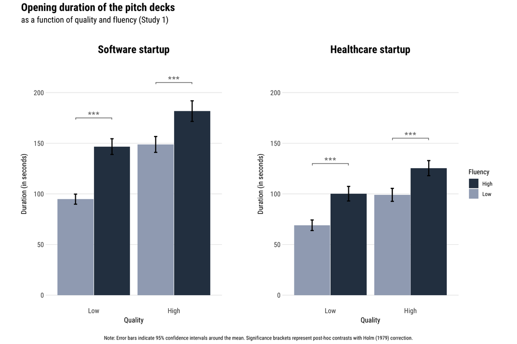

(a) Opening duration. *** p < .001.

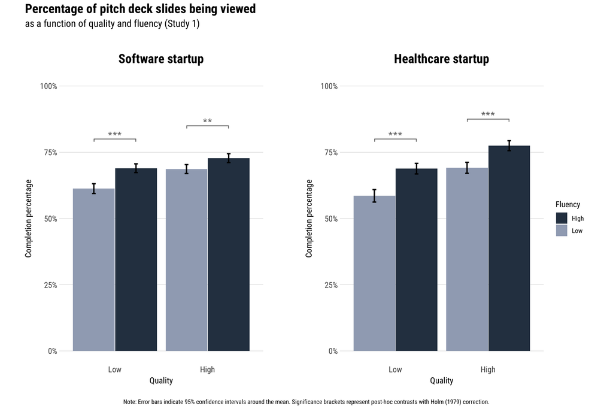

(b) Completion percentage. ** p < .01; *** p < .001.

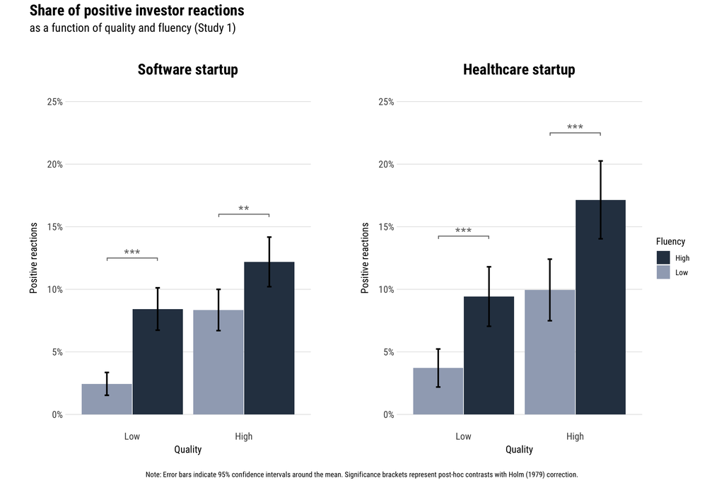

(c) Positive reactions. ** p < .01; *** p < .001.

Figure 2: Results of the field experiment

```r
# positive reactions
positive_1 + positive_2 + plot_layout(guides = 'collect') +
  plot_annotation(
  title = "Share of positive investor reactions",
  subtitle = "as a function of quality and fluency (Study 1)",
  caption = "Note: Error bars indicate 95% confidence intervals around the mean. Significance brackets represent post-hoc contrasts with Holm (1979) correction.",
  # tag_levels = 'A'
) & theme(
  plot.title = element_text(size = 18, family = "Roboto Condensed", face = "bold"),
  plot.subtitle = element_text(size = 14, family = "Roboto Condensed"),
  plot.caption = element_text(hjust=.5, family = "Roboto Condensed", margin = margin(t = -10, r = 0, b = 0, l = 0)),
)
```

## 7 Appendix: Conditional positive reactions

In this section, we report the results for positive reactions when restricting the sample to only participants who replied.

## 7.1 Descriptives

Table 14 shows a breakdown of the reply rate and the positive reactions per fluency and quality condition.

```r
# combine data
pos_given_reply_data <- bind_rows(list(
  Software = d_sw |> select(Fluency = fluency, Quality = quality, reply, positive_given_reply, investments, type, gender, location) |> mutate(n_mails = n_mails_sw),
  Healthcare = d_hc |> select(Fluency = fluency, Quality = quality, reply, positive_given_reply, investments, type, gender, location) |> mutate(n_mails = n_mails_hc)),
  .id = "Startup")
# convert Startup to factor, change order of levels
pos_given_reply_data$Startup <- factor(pos_given_reply_data$Startup, levels = c("Software", "Healthcare"))

# create table
pos_given_reply_data |>
  group_by(Startup, Fluency, Quality) |>
  summarize(
    `Clicks` = scales::comma(n()),
    `Replies ` = scales::comma(sum(reply)),
    `% Reply Rate ` = sprintf('%.2f', mean(reply)*100),
    `Pos. Reaction ` = scales::comma(sum(positive_given_reply, na.rm=T)),
    `% Pos. Reaction Rate ` = sprintf('%.2f', mean(positive_given_reply, na.rm=T)*100),
  ) |> kbl() |> kable_styling() |>
  row_spec(c(4), extra_css = "border-bottom: 1px solid")
```

Table 14: Breakdown of positive email reactions per startup, fluency, and quality condition

| Startup | Fluency | Quality | Clicks | Replies | % Reply Rate | Pos. Reaction | % Pos. Reaction Rate |
| --- | --- | --- | --- | --- | --- | --- | --- |
| Software | high | high | 1,091 | 245 | 22.46 | 133 | 54.29 |
| Software | high | low | 1,080 | 238 | 22.04 | 91 | 38.24 |
| Software | low | high | 1,126 | 233 | 20.69 | 94 | 40.34 |
| Software | low | low | 1,146 | 228 | 19.90 | 28 | 12.28 |
| Healthcare | high | high | 589 | 209 | 35.48 | 101 | 48.33 |
| Healthcare | high | low | 605 | 196 | 32.40 | 57 | 29.08 |
| Healthcare | low | high | 593 | 180 | 30.35 | 59 | 32.78 |
| Healthcare | low | low | 620 | 172 | 27.74 | 23 | 13.37 |

## 7.2 Results

We re-estimated the binary logit models (with control variables) reported in Table 7 and Table 12, now predicting whether there was a positive reaction to the emails conditional on investors having replied. Thus, for this analysis, the sample is a subset of the full sample (i.e., only investors who replied to the emails, N = 944 software startup, N = 757 healthcare startup). Table 15 shows the results of these models for the software and healthcare startup.

```r
d <- pos_given_reply_data

# 2 tables witch 2 colmuns each version

# convert conditions into factors
d$fluency <- as.factor(d$Fluency)
d$quality <- as.factor(d$Quality)

# relevel factor levels
d$quality <- relevel(d$quality, 'high')
d$fluency <- relevel(d$fluency, 'high')

# convert factor into effect coding
contrasts(d$fluency) <- contr.sum
contrasts(d$quality) <- contr.sum


# run regressions
glm_tbl(glm(positive_given_reply ~ fluency * quality + investments + type + gender + location, family = binomial(link = "logit"), d |> filter(Startup == "Software")), coef_digits = 3) -> temp_positive_given_reply_sw
glm_tbl(glm(positive_given_reply ~ fluency * quality + investments + type + gender + location, family = binomial(link = "logit"), d |> filter(Startup == "Healthcare")), coef_digits = 3) -> temp_positive_given_reply_hc

# put results together
temp <- bind_cols(temp_positive_given_reply_sw,
                  temp_positive_given_reply_hc[,-1]) |>
  mutate(term = c("Intercept", "Fluency", "Quality", "Investment experience",
               "Investor type [Venture Capital]", "Gender [Male]", "Country [Brazil]",
               "Country [Canada]", "Country [China]", "Country [France]",
               "Country [Germany]", "Country [India]", "Country [Israel]",
               "Country [Singapore]", "Country [United Kingdom]",
               "Fluency × Quality", "Tjur's R<sup>2</sup>"))

# change order of rows: put interaction after main effects
temp |> arrange(term %notin% c("Intercept", "Fluency", "Quality", "Fluency × Quality")) -> temp
# change column names
names(temp) <- c("", rep(c("Coeff.", "SE", "z", "p"), 2))

# create final table
temp |>
  kbl(escape = FALSE, align = "lcccccccc") |> kable_styling() |>
  add_header_above(c(" " = 1, "Software Startup" = 4, "Healthcare Startup" = 4)) |>
  row_spec(c(4,16), extra_css = "border-bottom: 1px solid")
```

Table 15: Binary logit models of positive reactions conditional on investors having replied

|  | Software Startup Coeff. | Software Startup SE | Software Startup z | Software Startup p | Healthcare Startup Coeff. | Healthcare Startup SE | Healthcare Startup z | Healthcare Startup p |
| --- | --- | --- | --- | --- | --- | --- | --- | --- |
| Intercept | -1.664 | 1.145 | -1.45 | .146 | 0.328 | 1.465 | 0.22 | .823 |
| Fluency | **0.519** | **0.077** | **6.75** | **< .001** | **0.407** | **0.087** | **4.66** | **< .001** |
| Quality | **0.558** | **0.077** | **7.26** | **< .001** | **0.504** | **0.087** | **5.77** | **< .001** |
| Fluency × Quality | **-0.236** | **0.077** | **-3.08** | **.002** | -0.079 | 0.087 | -0.91 | .364 |
| Investment experience | 0.005 | 0.016 | 0.30 | .766 | -0.038 | 0.064 | -0.59 | .555 |
| Investor type [Venture Capital] | -0.111 | 0.187 | -0.59 | .553 | -0.140 | 0.198 | -0.71 | .478 |
| Gender [Male] | 0.063 | 0.248 | 0.26 | .798 | **-0.628** | **0.253** | **-2.49** | **.013** |
| Country [Brazil] | 1.098 | 1.231 | 0.89 | .372 | -0.263 | 1.521 | -0.17 | .863 |
| Country [Canada] | 1.375 | 1.830 | 0.75 | .452 | -0.766 | 1.563 | -0.49 | .624 |
| Country [China] | 0.580 | 1.292 | 0.45 | .654 | -0.162 | 1.491 | -0.11 | .913 |
| Country [France] | 1.295 | 1.220 | 1.06 | .288 | -0.269 | 1.505 | -0.18 | .858 |
| Country [Germany] | 0.644 | 1.214 | 0.53 | .596 | -0.733 | 1.567 | -0.47 | .640 |
| Country [India] | 1.055 | 1.247 | 0.85 | .397 | 0.053 | 1.678 | 0.03 | .975 |
| Country [Israel] | 1.636 | 1.280 | 1.28 | .201 | -0.327 | 1.538 | -0.21 | .832 |
| Country [Singapore] | 0.818 | 1.166 | 0.70 | .483 | -0.582 | 1.464 | -0.40 | .691 |
| Country [United Kingdom] | 0.956 | 1.133 | 0.84 | .399 | -0.565 | 1.443 | -0.39 | .695 |
| Tjur's R<sup>2</sup> | .102 |  |  |  | .084 |  |  |  |

## Footnotes

[^1]: Two independent raters blind to our hypotheses rated all email replies as to whether the content demonstrates investor interest. For the software startup, the interrater agreement was 97.16% (Cohen’s κ = 0.939). For the healthcare startup, the interrater agreement was 96.45% (Cohen’s κ = 0.919). All cases for which the raters did not agree were resolved by the authors of this paper.